# DINOv2 Comprehensive Embedding Evaluation — Before Fine-Tuning

This notebook performs a rigorous evaluation of **frozen pretrained DINOv2 embeddings** for the wheat-grain dataset.

## Experiment plan

1. **Normalization + Feature Redundancy**
   - Original
   - Gray-World (`p=1`)
   - Shades-of-Gray (`p=4`, `p=6`, `p=8`)
   - Max-RGB
   - `CLS`, `mean patch-token`, and `CLS + mean-patch` embeddings
   - PCA redundancy, effective rank, correlation, class structure
2. **Robustness**
   - Blur
   - Gaussian noise
   - Brightness
   - Contrast
   - Warm/cool illumination cast
   - Resolution degradation
3. **DINOv2 Size Comparison**
   - ViT-S/14
   - ViT-B/14
4. **Final evidence**
   - Class separability
   - Source-image-excluded nearest-neighbor consistency
   - Feature redundancy
   - Robustness
   - Runtime / GPU memory
   - Model-size trade-off

### Experimental rules

- No DINOv2 fine-tuning.
- No downstream classifier training.
- Same representative subset in every experiment.
- Balanced sampling by class with source-image diversity.
- Same-source grains are excluded from KNN evaluation.
- Color constancy is estimated using grain pixels only.
- Aspect ratio is preserved before DINOv2 resize.
- Embeddings are cached so the experiment can resume safely.

## 1. Install dependencies

```python
%pip install -q torch torchvision opencv-python pillow pandas numpy matplotlib scikit-learn pyyaml tqdm
```

```
c:\Users\alool\Desktop\Codes\Python\Test_RFDeter\.venv\Scripts\python.exe: No module named pip
```

## 2. Imports and reproducibility

```python
from __future__ import annotations

import gc
import json
import random
import time
from functools import lru_cache
from pathlib import Path
from typing import Dict, Optional, Tuple

import cv2
import yaml
import numpy as np
import pandas as pd
import matplotlib.pyplot as plt

from PIL import Image
from tqdm.auto import tqdm

import torch
from torch.utils.data import Dataset, DataLoader
from torchvision import transforms

from sklearn.decomposition import PCA
from sklearn.metrics import silhouette_score

SEED = 42

random.seed(SEED)
np.random.seed(SEED)
torch.manual_seed(SEED)

if torch.cuda.is_available():
    torch.cuda.manual_seed_all(SEED)

DEVICE = "cuda" if torch.cuda.is_available() else "cpu"

print("PyTorch:", torch.__version__)
print("Device :", DEVICE)

if DEVICE == "cuda":
    print("GPU    :", torch.cuda.get_device_name(0))
```

```
PyTorch: 2.13.0+cu130
Device : cuda
GPU    : NVIDIA GeForce RTX 3050 Ti Laptop GPU
```

## 3. Experiment configuration

```python
PROJECT_ROOT = Path(r"C:\Users\alool\Desktop\Codes\Python\Test_RFDeter")
DATASET_DIR = PROJECT_ROOT / "wheatdecv1_seg"

OUTPUT_DIR = PROJECT_ROOT / "notebooks_Test_DinoV2" / "dinov2_comprehensive_eval"
CACHE_DIR = OUTPUT_DIR / "embedding_cache"
RESULTS_DIR = OUTPUT_DIR / "results"

for path in [OUTPUT_DIR, CACHE_DIR, RESULTS_DIR]:
    path.mkdir(parents=True, exist_ok=True)

# Representative evaluation set.
# For 3 classes this targets ~3000 grains total.
TARGET_PER_CLASS = 1000

# Keep expensive pairwise metrics bounded.
MAX_METRIC_SAMPLES = 3000

# DINOv2 input.
IMAGE_SIZE = 518
RESIZE_MODE = "aspect_pad"
MASK_BACKGROUND = 127
PADDING_RATIO = 0.08

# Robust color-constancy estimation.
COLOR_CONSTANCY_MIN_INTENSITY = 5
COLOR_CONSTANCY_MAX_INTENSITY = 250

# Conservative laptop-GPU batch sizes.
# Automatic OOM retry is implemented later.
MODEL_CONFIGS = {
    "vit_s14": {
        "hub_name": "dinov2_vits14",
        "initial_batch_size": 32,
    },
    "vit_b14": {
        "hub_name": "dinov2_vitb14",
        "initial_batch_size": 8,
    },
}

# All are obtained from the same DINO forward pass.
EMBEDDING_MODES = [
    "cls",
    "mean_patch",
    "cls_mean_concat",
]

NORMALIZATION_SPECS = [
    {"name": "original",       "kind": "none"},
    {"name": "gray_world_p1",  "kind": "shades_of_gray", "p": 1},
    {"name": "shades_gray_p4", "kind": "shades_of_gray", "p": 4},
    {"name": "shades_gray_p6", "kind": "shades_of_gray", "p": 6},
    {"name": "shades_gray_p8", "kind": "shades_of_gray", "p": 8},
    {"name": "max_rgb",        "kind": "max_rgb"},
]

ROBUSTNESS_SPECS = [
    {"name": "clean",               "kind": "none"},

    {"name": "blur_mild",           "kind": "gaussian_blur", "sigma": 1.0},
    {"name": "blur_strong",         "kind": "gaussian_blur", "sigma": 2.0},

    {"name": "noise_mild",          "kind": "gaussian_noise", "std": 5.0},
    {"name": "noise_strong",        "kind": "gaussian_noise", "std": 15.0},

    {"name": "brightness_dark",     "kind": "brightness", "factor": 0.75},
    {"name": "brightness_bright",   "kind": "brightness", "factor": 1.25},

    {"name": "contrast_low",        "kind": "contrast", "factor": 0.75},
    {"name": "contrast_high",       "kind": "contrast", "factor": 1.25},

    {"name": "illumination_warm",   "kind": "channel_gain", "gains": [1.12, 1.00, 0.88]},
    {"name": "illumination_cool",   "kind": "channel_gain", "gains": [0.88, 1.00, 1.12]},

    {"name": "resolution_50pct",    "kind": "resolution", "scale": 0.50},
    {"name": "resolution_25pct",    "kind": "resolution", "scale": 0.25},
]

# ViT-S runs the full robustness matrix.
# ViT-B defaults to clean original + clean best normalization.
RUN_VITB_ALL_ROBUSTNESS = False

USE_CACHE = True
FORCE_RECOMPUTE = False

print("Dataset:", DATASET_DIR)
print("Output :", OUTPUT_DIR)
print("Target per class:", TARGET_PER_CLASS)
```

```
Dataset: C:\Users\alool\Desktop\Codes\Python\Test_RFDeter\wheatdecv1_seg
Output : C:\Users\alool\Desktop\Codes\Python\Test_RFDeter\notebooks_Test_DinoV2\dinov2_comprehensive_eval
Target per class: 1000
```

## 4. Dataset discovery

```python
IMAGE_EXTENSIONS = {".jpg", ".jpeg", ".png", ".bmp", ".tif", ".tiff", ".webp"}

def read_class_names(dataset_dir: Path):
    yaml_candidates = list(dataset_dir.glob("*.yaml")) + list(dataset_dir.glob("*.yml"))

    for yaml_path in yaml_candidates:
        try:
            cfg = yaml.safe_load(yaml_path.read_text(encoding="utf-8"))
            names = cfg.get("names")

            if isinstance(names, list):
                return {i: str(name) for i, name in enumerate(names)}, yaml_path

            if isinstance(names, dict):
                return {int(k): str(v) for k, v in names.items()}, yaml_path

        except Exception:
            pass

    return {}, None


def find_split_pairs(dataset_dir: Path):
    aliases = [("train", "train"), ("valid", "valid"), ("val", "val"), ("test", "test")]
    found = []

    for split_name, folder in aliases:
        image_dir = dataset_dir / folder / "images"
        label_dir = dataset_dir / folder / "labels"

        if image_dir.exists() and label_dir.exists():
            found.append((split_name, image_dir, label_dir))

    for split_name, folder in aliases:
        image_dir = dataset_dir / "images" / folder
        label_dir = dataset_dir / "labels" / folder

        candidate = (split_name, image_dir, label_dir)

        if image_dir.exists() and label_dir.exists() and candidate not in found:
            found.append(candidate)

    return found


CLASS_NAMES, YAML_PATH = read_class_names(DATASET_DIR)
SPLIT_DIRS = find_split_pairs(DATASET_DIR)

print("YAML   :", YAML_PATH)
print("Classes:", CLASS_NAMES)

if not SPLIT_DIRS:
    raise FileNotFoundError(
        "Could not find YOLO train/valid/test image-label directories."
    )

for split_name, image_dir, label_dir in SPLIT_DIRS:
    print(f"{split_name:>5} | images={image_dir} | labels={label_dir}")
```

```
YAML   : C:\Users\alool\Desktop\Codes\Python\Test_RFDeter\wheatdecv1_seg\data.yaml
Classes: {0: 'bad seed', 1: 'healthy seed', 2: 'impurity'}
train | images=C:\Users\alool\Desktop\Codes\Python\Test_RFDeter\wheatdecv1_seg\train\images | labels=C:\Users\alool\Desktop\Codes\Python\Test_RFDeter\wheatdecv1_seg\train\labels
valid | images=C:\Users\alool\Desktop\Codes\Python\Test_RFDeter\wheatdecv1_seg\valid\images | labels=C:\Users\alool\Desktop\Codes\Python\Test_RFDeter\wheatdecv1_seg\valid\labels
 test | images=C:\Users\alool\Desktop\Codes\Python\Test_RFDeter\wheatdecv1_seg\test\images | labels=C:\Users\alool\Desktop\Codes\Python\Test_RFDeter\wheatdecv1_seg\test\labels
```

## 5. Parse YOLO segmentation labels

```python
def parse_yolo_segmentation_line(line: str):
    parts = line.strip().split()

    if len(parts) < 7:
        return None

    class_id = int(float(parts[0]))
    coords = np.asarray([float(v) for v in parts[1:]], dtype=np.float32)

    if coords.size % 2 != 0:
        return None

    polygon_norm = coords.reshape(-1, 2)

    if polygon_norm.shape[0] < 3:
        return None

    return class_id, polygon_norm


records = []

for split_name, image_dir, label_dir in SPLIT_DIRS:
    image_paths = [
        path
        for path in image_dir.rglob("*")
        if path.suffix.lower() in IMAGE_EXTENSIONS
    ]

    for image_path in tqdm(image_paths, desc=f"Parse {split_name}"):
        label_path = label_dir / f"{image_path.stem}.txt"

        if not label_path.exists():
            relative_label = image_path.relative_to(image_dir).with_suffix(".txt")
            label_path = label_dir / relative_label

        if not label_path.exists():
            continue

        try:
            with Image.open(image_path) as image:
                width, height = image.size
        except Exception:
            continue

        lines = label_path.read_text(
            encoding="utf-8",
            errors="ignore",
        ).splitlines()

        for instance_idx, line in enumerate(lines):
            parsed = parse_yolo_segmentation_line(line)

            if parsed is None:
                continue

            class_id, polygon_norm = parsed

            polygon_px = polygon_norm.copy()
            polygon_px[:, 0] *= width
            polygon_px[:, 1] *= height

            records.append({
                "split": split_name,
                "image_path": str(image_path),
                "label_path": str(label_path),
                "instance_idx": int(instance_idx),
                "class_id": int(class_id),
                "class_name": CLASS_NAMES.get(class_id, f"class_{class_id}"),
                "polygon_px": polygon_px,
                "image_width": int(width),
                "image_height": int(height),
            })

instances_df = pd.DataFrame(records)

if instances_df.empty:
    raise ValueError(
        "No segmentation polygons were parsed. Verify YOLO segmentation labels."
    )

print("Unique images:", instances_df["image_path"].nunique())
print("Grain instances:", len(instances_df))

display(
    instances_df.groupby(["split", "class_id", "class_name"])
    .size()
    .reset_index(name="instances")
)
```

```
Unique images: 3758
Grain instances: 234796
```

|  | split | class_id | class_name | instances |
| --- | --- | --- | --- | --- |
| 0 | test | 0 | bad seed | 3095 |
| 1 | test | 1 | healthy seed | 1345 |
| 2 | test | 2 | impurity | 45 |
| 3 | train | 0 | bad seed | 146129 |
| 4 | train | 1 | healthy seed | 67937 |
| 5 | train | 2 | impurity | 2005 |
| 6 | valid | 0 | bad seed | 9670 |
| 7 | valid | 1 | healthy seed | 4486 |
| 8 | valid | 2 | impurity | 84 |

## 6. Balanced source-diverse representative subset

```python
def diverse_balanced_sample(
    df: pd.DataFrame,
    target_per_class: int,
    seed: int = 42,
) -> pd.DataFrame:
    # The within-source rank makes the sampler prefer broad source-image
    # coverage before selecting many grains from one image.
    pieces = []

    for class_id, class_df in df.groupby("class_id"):
        class_df = class_df.sample(
            frac=1.0,
            random_state=seed + int(class_id),
        ).copy()

        class_df["_within_source_rank"] = (
            class_df.groupby("image_path").cumcount()
        )

        class_df = class_df.sort_values(
            ["_within_source_rank", "image_path", "instance_idx"]
        )

        n_take = min(target_per_class, len(class_df))

        selected = class_df.iloc[:n_take].drop(
            columns="_within_source_rank"
        )

        pieces.append(selected)

    subset = pd.concat(pieces, ignore_index=True)

    subset = subset.sample(
        frac=1.0,
        random_state=seed,
    ).reset_index(drop=True)

    subset["row_id"] = np.arange(len(subset), dtype=np.int64)

    return subset


subset_df = diverse_balanced_sample(
    instances_df,
    target_per_class=TARGET_PER_CLASS,
    seed=SEED,
)

print("Subset grains:", len(subset_df))
print("Source images:", subset_df["image_path"].nunique())

display(
    subset_df.groupby(["class_id", "class_name"])
    .agg(
        grains=("row_id", "size"),
        source_images=("image_path", "nunique"),
    )
    .reset_index()
)

manifest = subset_df[
    [
        "row_id",
        "split",
        "image_path",
        "label_path",
        "instance_idx",
        "class_id",
        "class_name",
    ]
].copy()

manifest["polygon_px"] = subset_df["polygon_px"].apply(
    lambda x: json.dumps(np.asarray(x, dtype=float).tolist())
)

manifest_path = RESULTS_DIR / "representative_subset_manifest.csv"
manifest.to_csv(manifest_path, index=False)

print("Saved:", manifest_path)
```

```
Subset grains: 3000
Source images: 2592
```

|  | class_id | class_name | grains | source_images |
| --- | --- | --- | --- | --- |
| 0 | 0 | bad seed | 1000 | 1000 |
| 1 | 1 | healthy seed | 1000 | 1000 |
| 2 | 2 | impurity | 1000 | 697 |

```
Saved: C:\Users\alool\Desktop\Codes\Python\Test_RFDeter\notebooks_Test_DinoV2\dinov2_comprehensive_eval\results\representative_subset_manifest.csv
```

## 7. Crop, mask, normalization, and perturbation functions

```python
@lru_cache(maxsize=64)
def _read_rgb_cached(image_path: str) -> np.ndarray:
    bgr = cv2.imread(image_path, cv2.IMREAD_COLOR)

    if bgr is None:
        raise ValueError(f"Could not read image: {image_path}")

    return cv2.cvtColor(bgr, cv2.COLOR_BGR2RGB)


def extract_crop_and_mask(
    image_path: str,
    polygon_px: np.ndarray,
    padding_ratio: float = 0.08,
) -> Tuple[np.ndarray, np.ndarray]:
    image_rgb = _read_rgb_cached(str(image_path))
    h, w = image_rgb.shape[:2]

    polygon = np.round(
        np.asarray(polygon_px)
    ).astype(np.int32)

    x, y, bw, bh = cv2.boundingRect(polygon)

    pad_x = int(round(bw * padding_ratio))
    pad_y = int(round(bh * padding_ratio))

    x1 = max(0, x - pad_x)
    y1 = max(0, y - pad_y)
    x2 = min(w, x + bw + pad_x)
    y2 = min(h, y + bh + pad_y)

    crop = image_rgb[y1:y2, x1:x2].copy()

    local_polygon = polygon.copy()
    local_polygon[:, 0] -= x1
    local_polygon[:, 1] -= y1

    mask = np.zeros(crop.shape[:2], dtype=np.uint8)
    cv2.fillPoly(mask, [local_polygon], 255)

    return crop, mask


def apply_mask_background(
    image_rgb: np.ndarray,
    mask: np.ndarray,
    background_value: int = 127,
) -> np.ndarray:
    background = np.full_like(
        image_rgb,
        int(background_value),
    )

    return np.where(
        mask[..., None] > 0,
        image_rgb,
        background,
    ).astype(np.uint8)


def _valid_color_pixels(
    image_rgb: np.ndarray,
    mask: Optional[np.ndarray],
) -> np.ndarray:
    pixels = (
        image_rgb[mask > 0]
        if mask is not None
        else image_rgb.reshape(-1, 3)
    )

    if pixels.size == 0:
        return pixels.astype(np.float32)

    pixels = pixels.astype(np.float32)

    intensity = pixels.mean(axis=1)

    valid = (
        (intensity >= COLOR_CONSTANCY_MIN_INTENSITY)
        & (intensity <= COLOR_CONSTANCY_MAX_INTENSITY)
    )

    if valid.sum() >= 10:
        pixels = pixels[valid]

    return pixels


def shades_of_gray_color_constancy(
    image_rgb: np.ndarray,
    mask: Optional[np.ndarray],
    p: float = 6.0,
    eps: float = 1e-6,
) -> np.ndarray:
    pixels = _valid_color_pixels(image_rgb, mask)

    if pixels.size == 0:
        return image_rgb.copy()

    pixels_01 = np.clip(
        pixels / 255.0,
        0.0,
        1.0,
    )

    illuminant = (
        np.mean(
            np.power(pixels_01, p),
            axis=0,
        )
        + eps
    ) ** (1.0 / p)

    target = float(np.mean(illuminant))

    gains = target / np.maximum(
        illuminant,
        eps,
    )

    corrected = (
        image_rgb.astype(np.float32)
        * gains.reshape(1, 1, 3)
    )

    return np.clip(
        corrected,
        0,
        255,
    ).astype(np.uint8)


def max_rgb_color_constancy(
    image_rgb: np.ndarray,
    mask: Optional[np.ndarray],
    eps: float = 1e-6,
) -> np.ndarray:
    pixels = _valid_color_pixels(image_rgb, mask)

    if pixels.size == 0:
        return image_rgb.copy()

    illuminant = np.maximum(
        pixels.max(axis=0),
        eps,
    )

    target = float(np.mean(illuminant))
    gains = target / illuminant

    corrected = (
        image_rgb.astype(np.float32)
        * gains.reshape(1, 1, 3)
    )

    return np.clip(
        corrected,
        0,
        255,
    ).astype(np.uint8)


def apply_normalization(
    image_rgb: np.ndarray,
    mask: np.ndarray,
    spec: dict,
) -> np.ndarray:
    kind = spec["kind"]

    if kind == "none":
        return image_rgb.copy()

    if kind == "shades_of_gray":
        return shades_of_gray_color_constancy(
            image_rgb,
            mask,
            p=float(spec["p"]),
        )

    if kind == "max_rgb":
        return max_rgb_color_constancy(
            image_rgb,
            mask,
        )

    raise ValueError(f"Unknown normalization kind: {kind}")


def apply_perturbation(
    image_rgb: np.ndarray,
    spec: dict,
    seed: int,
) -> np.ndarray:
    kind = spec["kind"]

    if kind == "none":
        return image_rgb.copy()

    image_f = image_rgb.astype(np.float32)

    if kind == "gaussian_blur":
        sigma = float(spec["sigma"])

        output = cv2.GaussianBlur(
            image_rgb,
            (0, 0),
            sigmaX=sigma,
            sigmaY=sigma,
        )

        return output.astype(np.uint8)

    if kind == "gaussian_noise":
        rng = np.random.default_rng(seed)

        noise = rng.normal(
            0.0,
            float(spec["std"]),
            size=image_f.shape,
        ).astype(np.float32)

        return np.clip(
            image_f + noise,
            0,
            255,
        ).astype(np.uint8)

    if kind == "brightness":
        factor = float(spec["factor"])

        return np.clip(
            image_f * factor,
            0,
            255,
        ).astype(np.uint8)

    if kind == "contrast":
        factor = float(spec["factor"])

        mean = image_f.mean(
            axis=(0, 1),
            keepdims=True,
        )

        output = (
            (image_f - mean) * factor
            + mean
        )

        return np.clip(
            output,
            0,
            255,
        ).astype(np.uint8)

    if kind == "channel_gain":
        gains = np.asarray(
            spec["gains"],
            dtype=np.float32,
        ).reshape(1, 1, 3)

        return np.clip(
            image_f * gains,
            0,
            255,
        ).astype(np.uint8)

    if kind == "resolution":
        scale = float(spec["scale"])

        h, w = image_rgb.shape[:2]

        low_w = max(1, int(round(w * scale)))
        low_h = max(1, int(round(h * scale)))

        low = cv2.resize(
            image_rgb,
            (low_w, low_h),
            interpolation=cv2.INTER_AREA,
        )

        restored = cv2.resize(
            low,
            (w, h),
            interpolation=cv2.INTER_CUBIC,
        )

        return restored.astype(np.uint8)

    raise ValueError(f"Unknown perturbation kind: {kind}")
```

## 8. DINOv2 preprocessing with aspect-ratio preservation

```python
DINO_NORMALIZE = transforms.Normalize(
    mean=(0.485, 0.456, 0.406),
    std=(0.229, 0.224, 0.225),
)

TO_TENSOR = transforms.ToTensor()


def pad_to_square(
    image: Image.Image,
    fill_value: int = 127,
) -> Image.Image:
    width, height = image.size
    side = max(width, height)

    canvas = Image.new(
        "RGB",
        (side, side),
        color=(fill_value, fill_value, fill_value),
    )

    left = (side - width) // 2
    top = (side - height) // 2

    canvas.paste(
        image,
        (left, top),
    )

    return canvas


def prepare_dino_tensor(
    image_rgb: np.ndarray,
    resize_mode: str = "aspect_pad",
) -> torch.Tensor:
    image = Image.fromarray(image_rgb)

    if resize_mode == "aspect_pad":
        image = pad_to_square(
            image,
            fill_value=MASK_BACKGROUND,
        )

    elif resize_mode != "stretch":
        raise ValueError(
            f"Unknown resize mode: {resize_mode}"
        )

    image = image.resize(
        (IMAGE_SIZE, IMAGE_SIZE),
        resample=Image.Resampling.BICUBIC,
    )

    tensor = TO_TENSOR(image)
    tensor = DINO_NORMALIZE(tensor)

    return tensor
```

## 9. Visual sanity check

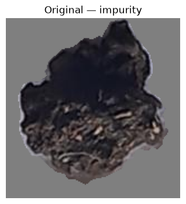

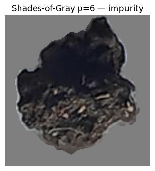

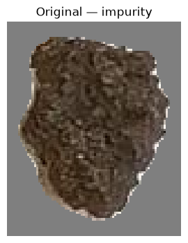

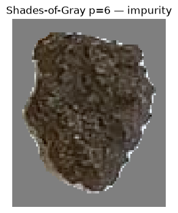

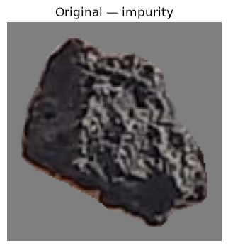

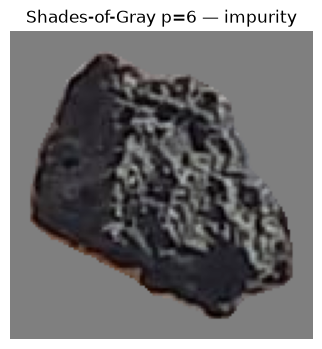

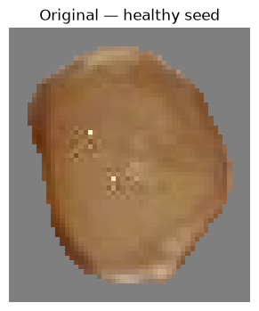

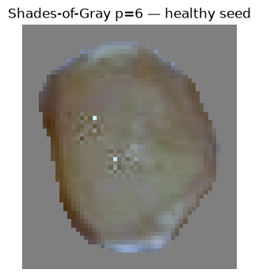

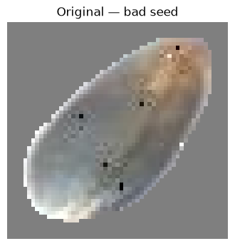

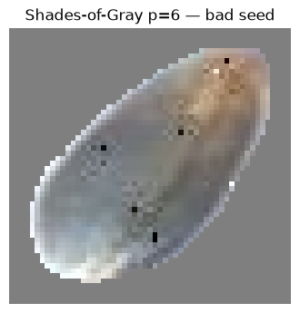

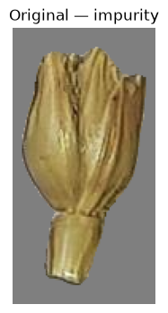

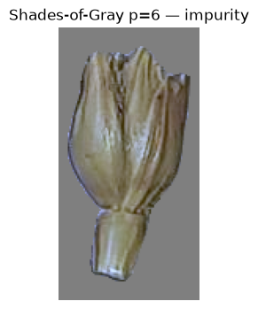

```python
def get_normalization_spec(name: str):
    for spec in NORMALIZATION_SPECS:
        if spec["name"] == name:
            return spec

    raise KeyError(name)


preview_rows = subset_df.sample(
    n=min(6, len(subset_df)),
    random_state=SEED,
)

for _, row in preview_rows.iterrows():
    crop, mask = extract_crop_and_mask(
        row["image_path"],
        row["polygon_px"],
        PADDING_RATIO,
    )

    original = apply_mask_background(
        crop,
        mask,
        MASK_BACKGROUND,
    )

    corrected = apply_normalization(
        crop,
        mask,
        get_normalization_spec("shades_gray_p6"),
    )

    corrected = apply_mask_background(
        corrected,
        mask,
        MASK_BACKGROUND,
    )

    plt.figure(figsize=(4, 4))
    plt.imshow(original)
    plt.title(f"Original — {row['class_name']}")
    plt.axis("off")
    plt.show()

    plt.figure(figsize=(4, 4))
    plt.imshow(corrected)
    plt.title(f"Shades-of-Gray p=6 — {row['class_name']}")
    plt.axis("off")
    plt.show()
```

## 10. Dataset for one experimental condition

```python
class GrainConditionDataset(Dataset):
    def __init__(
        self,
        dataframe: pd.DataFrame,
        normalization_spec: dict,
        perturbation_spec: dict,
        resize_mode: str,
    ):
        self.df = dataframe.reset_index(drop=True)
        self.normalization_spec = normalization_spec
        self.perturbation_spec = perturbation_spec
        self.resize_mode = resize_mode

    def __len__(self):
        return len(self.df)

    def __getitem__(self, idx):
        row = self.df.iloc[idx]

        crop, mask = extract_crop_and_mask(
            row["image_path"],
            row["polygon_px"],
            PADDING_RATIO,
        )

        # Realistic order:
        # acquisition degradation -> color constancy -> mask -> DINO preprocessing.
        perturbed = apply_perturbation(
            crop,
            self.perturbation_spec,
            seed=SEED + int(row["row_id"]),
        )

        normalized = apply_normalization(
            perturbed,
            mask,
            self.normalization_spec,
        )

        masked = apply_mask_background(
            normalized,
            mask,
            MASK_BACKGROUND,
        )

        tensor = prepare_dino_tensor(
            masked,
            self.resize_mode,
        )

        return tensor, int(row["row_id"])
```

## 11. DINOv2 model loading and safe cached extraction

```python
def load_dino_model(model_key: str):
    config = MODEL_CONFIGS[model_key]

    try:
        model = torch.hub.load(
            "facebookresearch/dinov2",
            config["hub_name"],
            pretrained=True,
            trust_repo=True,
        )
    except TypeError:
        model = torch.hub.load(
            "facebookresearch/dinov2",
            config["hub_name"],
            pretrained=True,
        )

    model = model.to(DEVICE)
    model.eval()

    for parameter in model.parameters():
        parameter.requires_grad = False

    num_params = sum(
        parameter.numel()
        for parameter in model.parameters()
    )

    return model, num_params


def release_model(model):
    del model
    gc.collect()

    if torch.cuda.is_available():
        torch.cuda.empty_cache()


def condition_cache_path(
    model_key: str,
    normalization_name: str,
    perturbation_name: str,
):
    filename = (
        f"{model_key}"
        f"__{normalization_name}"
        f"__{perturbation_name}"
        f"__{RESIZE_MODE}.npz"
    )

    return CACHE_DIR / filename


def _extract_once(
    model,
    model_key: str,
    normalization_spec: dict,
    perturbation_spec: dict,
    batch_size: int,
):
    dataset = GrainConditionDataset(
        subset_df,
        normalization_spec,
        perturbation_spec,
        RESIZE_MODE,
    )

    loader = DataLoader(
        dataset,
        batch_size=batch_size,
        shuffle=False,
        num_workers=0,
        pin_memory=(DEVICE == "cuda"),
    )

    cls_parts = []
    patch_parts = []
    row_id_parts = []

    if DEVICE == "cuda":
        torch.cuda.reset_peak_memory_stats()

    started = time.perf_counter()

    with torch.inference_mode():
        for images, row_ids in tqdm(
            loader,
            desc=(
                f"{model_key} | "
                f"{normalization_spec['name']} | "
                f"{perturbation_spec['name']} | "
                f"bs={batch_size}"
            ),
        ):
            images = images.to(
                DEVICE,
                non_blocking=True,
            )

            if DEVICE == "cuda":
                with torch.autocast(
                    device_type="cuda",
                    dtype=torch.float16,
                ):
                    features = model.forward_features(images)

                    cls_embedding = features["x_norm_clstoken"]

                    mean_patch = (
                        features["x_norm_patchtokens"]
                        .mean(dim=1)
                    )
            else:
                features = model.forward_features(images)

                cls_embedding = features["x_norm_clstoken"]

                mean_patch = (
                    features["x_norm_patchtokens"]
                    .mean(dim=1)
                )

            cls_parts.append(
                cls_embedding.float().cpu().numpy()
            )

            patch_parts.append(
                mean_patch.float().cpu().numpy()
            )

            row_id_parts.append(
                row_ids.numpy()
            )

    elapsed = time.perf_counter() - started

    cls_array = np.concatenate(
        cls_parts,
        axis=0,
    )

    patch_array = np.concatenate(
        patch_parts,
        axis=0,
    )

    row_ids = np.concatenate(
        row_id_parts,
        axis=0,
    )

    concat_array = np.concatenate(
        [cls_array, patch_array],
        axis=1,
    )

    if DEVICE == "cuda":
        peak_gpu_mb = (
            torch.cuda.max_memory_allocated()
            / (1024 ** 2)
        )
    else:
        peak_gpu_mb = np.nan

    return {
        "row_ids": row_ids,
        "cls": cls_array,
        "mean_patch": patch_array,
        "cls_mean_concat": concat_array,
        "elapsed_sec": float(elapsed),
        "grains_per_sec": float(
            len(row_ids) / max(elapsed, 1e-9)
        ),
        "peak_gpu_mb": float(peak_gpu_mb),
        "batch_size": int(batch_size),
    }


def extract_embeddings(
    model,
    model_key: str,
    normalization_spec: dict,
    perturbation_spec: dict,
    initial_batch_size: int,
):
    cache_path = condition_cache_path(
        model_key,
        normalization_spec["name"],
        perturbation_spec["name"],
    )

    expected_row_ids = (
        subset_df["row_id"]
        .to_numpy()
    )

    if (
        USE_CACHE
        and cache_path.exists()
        and not FORCE_RECOMPUTE
    ):
        cached = np.load(
            cache_path,
            allow_pickle=False,
        )

        if np.array_equal(
            cached["row_ids"],
            expected_row_ids,
        ):
            return {
                "row_ids": cached["row_ids"],
                "cls": cached["cls"],
                "mean_patch": cached["mean_patch"],
                "cls_mean_concat": cached["cls_mean_concat"],
                "elapsed_sec": float(cached["elapsed_sec"]),
                "grains_per_sec": float(cached["grains_per_sec"]),
                "peak_gpu_mb": float(cached["peak_gpu_mb"]),
                "batch_size": int(cached["batch_size"]),
                "from_cache": True,
            }

        print(
            "Ignoring stale cache:",
            cache_path.name,
        )

    batch_size = int(initial_batch_size)

    while batch_size >= 1:
        try:
            result = _extract_once(
                model,
                model_key,
                normalization_spec,
                perturbation_spec,
                batch_size,
            )

            result["from_cache"] = False

            np.savez_compressed(
                cache_path,
                row_ids=result["row_ids"],
                cls=result["cls"],
                mean_patch=result["mean_patch"],
                cls_mean_concat=result["cls_mean_concat"],
                elapsed_sec=np.asarray(
                    result["elapsed_sec"],
                    dtype=np.float64,
                ),
                grains_per_sec=np.asarray(
                    result["grains_per_sec"],
                    dtype=np.float64,
                ),
                peak_gpu_mb=np.asarray(
                    result["peak_gpu_mb"],
                    dtype=np.float64,
                ),
                batch_size=np.asarray(
                    result["batch_size"],
                    dtype=np.int64,
                ),
            )

            return result

        except RuntimeError as error:
            message = str(error).lower()

            if "out of memory" not in message:
                raise

            print(
                f"CUDA OOM at batch_size={batch_size}. "
                "Retrying with half."
            )

            if torch.cuda.is_available():
                torch.cuda.empty_cache()

            gc.collect()
            batch_size //= 2

    raise RuntimeError(
        "Inference failed even with batch_size=1."
    )
```

## 12. Evaluation metadata

```python
meta_eval_df = subset_df[
    [
        "row_id",
        "image_path",
        "class_id",
        "class_name",
        "split",
    ]
].copy().reset_index(drop=True)

clean_spec = next(
    spec
    for spec in ROBUSTNESS_SPECS
    if spec["name"] == "clean"
)

display(meta_eval_df.head())
```

|  | row_id | image_path | class_id | class_name | split |
| --- | --- | --- | --- | --- | --- |
| 0 | 0 | C:\Users\alool\Desktop\Codes\Python\Test_RFDet... | 1 | healthy seed | train |
| 1 | 1 | C:\Users\alool\Desktop\Codes\Python\Test_RFDet... | 1 | healthy seed | train |
| 2 | 2 | C:\Users\alool\Desktop\Codes\Python\Test_RFDet... | 1 | healthy seed | train |
| 3 | 3 | C:\Users\alool\Desktop\Codes\Python\Test_RFDet... | 0 | bad seed | train |
| 4 | 4 | C:\Users\alool\Desktop\Codes\Python\Test_RFDet... | 2 | impurity | train |

## 13. Class-structure metrics

```python
def l2_normalize_rows(
    embeddings: np.ndarray,
    eps: float = 1e-12,
) -> np.ndarray:
    norms = np.linalg.norm(
        embeddings,
        axis=1,
        keepdims=True,
    )

    return embeddings / np.maximum(
        norms,
        eps,
    )


def stratified_metric_indices(
    meta_df: pd.DataFrame,
    max_samples: int,
):
    if len(meta_df) <= max_samples:
        return np.arange(len(meta_df))

    classes = sorted(
        meta_df["class_id"].unique()
    )

    per_class = max(
        1,
        max_samples // len(classes),
    )

    selected = []

    for class_id in classes:
        indices = meta_df.index[
            meta_df["class_id"] == class_id
        ].to_numpy()

        rng = np.random.default_rng(
            SEED + int(class_id)
        )

        n = min(
            per_class,
            len(indices),
        )

        selected.extend(
            rng.choice(
                indices,
                size=n,
                replace=False,
            ).tolist()
        )

    selected = np.asarray(
        selected,
        dtype=int,
    )

    return np.sort(selected)


def class_centroids(
    normalized_embeddings: np.ndarray,
    labels: np.ndarray,
):
    centroids = {}

    for class_id in np.unique(labels):
        centroid = normalized_embeddings[
            labels == class_id
        ].mean(axis=0)

        centroid /= max(
            np.linalg.norm(centroid),
            1e-12,
        )

        centroids[int(class_id)] = centroid

    return centroids


def centroid_similarity_summary(
    normalized_embeddings: np.ndarray,
    labels: np.ndarray,
):
    centroids = class_centroids(
        normalized_embeddings,
        labels,
    )

    ids = sorted(
        centroids.keys()
    )

    rows = []

    for index, class_a in enumerate(ids):
        for class_b in ids[index + 1:]:
            similarity = float(
                np.dot(
                    centroids[class_a],
                    centroids[class_b],
                )
            )

            rows.append({
                "class_a": CLASS_NAMES.get(
                    class_a,
                    str(class_a),
                ),
                "class_b": CLASS_NAMES.get(
                    class_b,
                    str(class_b),
                ),
                "cosine_similarity": similarity,
            })

    pair_df = pd.DataFrame(rows)

    if pair_df.empty:
        return np.nan, np.nan, np.nan, pair_df

    mean_similarity = float(
        pair_df["cosine_similarity"].mean()
    )

    max_similarity = float(
        pair_df["cosine_similarity"].max()
    )

    bad_healthy_similarity = np.nan

    for _, row in pair_df.iterrows():
        name_a = str(row["class_a"]).lower()
        name_b = str(row["class_b"]).lower()

        has_bad = (
            "bad" in name_a
            or "bad" in name_b
        )

        has_healthy = (
            "healthy" in name_a
            or "healthy" in name_b
        )

        if has_bad and has_healthy:
            bad_healthy_similarity = float(
                row["cosine_similarity"]
            )
            break

    return (
        mean_similarity,
        max_similarity,
        bad_healthy_similarity,
        pair_df,
    )


def knn_purity_excluding_same_source(
    normalized_embeddings: np.ndarray,
    labels: np.ndarray,
    source_images: np.ndarray,
    k: int = 5,
):
    similarity = (
        normalized_embeddings
        @ normalized_embeddings.T
    )

    same_source = (
        source_images[:, None]
        == source_images[None, :]
    )

    similarity[same_source] = -np.inf

    valid_rows = np.isfinite(
        similarity
    ).any(axis=1)

    if not valid_rows.any():
        return np.nan, np.nan

    valid_similarity = similarity[
        valid_rows
    ]

    valid_labels = labels[
        valid_rows
    ]

    top1_index = np.argmax(
        valid_similarity,
        axis=1,
    )

    top1_accuracy = float(
        np.mean(
            labels[top1_index]
            == valid_labels
        )
    )

    k_effective = min(
        k,
        max(1, similarity.shape[1] - 1),
    )

    topk_indices = np.argpartition(
        valid_similarity,
        -k_effective,
        axis=1,
    )[:, -k_effective:]

    topk_labels = labels[
        topk_indices
    ]

    topk_purity = float(
        np.mean(
            np.mean(
                topk_labels
                == valid_labels[:, None],
                axis=1,
            )
        )
    )

    return (
        top1_accuracy,
        topk_purity,
    )


def separation_metrics(
    embeddings: np.ndarray,
    meta_df: pd.DataFrame,
):
    metric_indices = stratified_metric_indices(
        meta_df,
        MAX_METRIC_SAMPLES,
    )

    X = embeddings[
        metric_indices
    ].astype(np.float32)

    metadata = (
        meta_df.iloc[metric_indices]
        .reset_index(drop=True)
    )

    labels = metadata[
        "class_id"
    ].to_numpy()

    source_images = metadata[
        "image_path"
    ].to_numpy()

    Xn = l2_normalize_rows(X)

    if len(np.unique(labels)) >= 2:
        silhouette = float(
            silhouette_score(
                Xn,
                labels,
                metric="cosine",
            )
        )
    else:
        silhouette = np.nan

    knn1, knn5 = (
        knn_purity_excluding_same_source(
            Xn,
            labels,
            source_images,
            k=5,
        )
    )

    (
        mean_centroid_similarity,
        max_centroid_similarity,
        bad_healthy_similarity,
        pair_df,
    ) = centroid_similarity_summary(
        Xn,
        labels,
    )

    pca2 = PCA(
        n_components=2,
        random_state=SEED,
    )

    pca2.fit(Xn)

    pca2_variance = float(
        pca2.explained_variance_ratio_.sum()
    )

    majority_chance = float(
        pd.Series(labels)
        .value_counts(normalize=True)
        .max()
    )

    metrics = {
        "silhouette_cosine": silhouette,
        "knn1_excl_same_image": knn1,
        "knn5_purity_excl_same_image": knn5,
        "mean_centroid_cosine": mean_centroid_similarity,
        "max_centroid_cosine": max_centroid_similarity,
        "bad_healthy_centroid_cosine": bad_healthy_similarity,
        "pca2_explained_variance": pca2_variance,
        "majority_chance": majority_chance,
    }

    return metrics, pair_df
```

## 14. Feature redundancy metrics

```python
def components_for_variance(
    cumulative_variance: np.ndarray,
    threshold: float,
) -> int:
    return int(
        np.searchsorted(
            cumulative_variance,
            threshold,
            side="left",
        )
        + 1
    )


def feature_redundancy_metrics(
    embeddings: np.ndarray,
):
    X = embeddings.astype(np.float32)

    if len(X) > MAX_METRIC_SAMPLES:
        rng = np.random.default_rng(SEED)

        indices = rng.choice(
            len(X),
            size=MAX_METRIC_SAMPLES,
            replace=False,
        )

        X = X[indices]

    centered = (
        X
        - X.mean(
            axis=0,
            keepdims=True,
        )
    )

    variances = centered.var(axis=0)

    near_zero_count = int(
        np.sum(
            variances < 1e-10
        )
    )

    pca = PCA(
        n_components=min(
            centered.shape[0],
            centered.shape[1],
        ),
        svd_solver="full",
        random_state=SEED,
    )

    pca.fit(centered)

    explained_ratio = (
        pca.explained_variance_ratio_
    )

    cumulative = np.cumsum(
        explained_ratio
    )

    components_90 = components_for_variance(
        cumulative,
        0.90,
    )

    components_95 = components_for_variance(
        cumulative,
        0.95,
    )

    components_99 = components_for_variance(
        cumulative,
        0.99,
    )

    eigenvalues = np.maximum(
        pca.explained_variance_,
        0.0,
    )

    eigenvalue_sum = eigenvalues.sum()

    if eigenvalue_sum > 0:
        probabilities = (
            eigenvalues
            / eigenvalue_sum
        )

        probabilities = probabilities[
            probabilities > 0
        ]

        effective_rank = float(
            np.exp(
                -np.sum(
                    probabilities
                    * np.log(probabilities)
                )
            )
        )

        participation_ratio = float(
            (eigenvalue_sum ** 2)
            / max(
                np.sum(eigenvalues ** 2),
                1e-12,
            )
        )
    else:
        effective_rank = np.nan
        participation_ratio = np.nan

    valid_dimensions = (
        variances >= 1e-10
    )

    if valid_dimensions.sum() >= 2:
        correlation = np.corrcoef(
            centered[:, valid_dimensions],
            rowvar=False,
        )

        absolute_correlation = np.abs(
            correlation
        )

        upper = absolute_correlation[
            np.triu_indices_from(
                absolute_correlation,
                k=1,
            )
        ]

        mean_abs_corr = float(
            np.nanmean(upper)
        )

        fraction_corr_090 = float(
            np.nanmean(
                upper >= 0.90
            )
        )

        fraction_corr_095 = float(
            np.nanmean(
                upper >= 0.95
            )
        )
    else:
        mean_abs_corr = np.nan
        fraction_corr_090 = np.nan
        fraction_corr_095 = np.nan

    metrics = {
        "embedding_dim": int(
            X.shape[1]
        ),
        "near_zero_variance_dims": near_zero_count,
        "pca_components_90": components_90,
        "pca_components_95": components_95,
        "pca_components_99": components_99,
        "effective_rank": effective_rank,
        "participation_ratio": participation_ratio,
        "mean_abs_feature_corr": mean_abs_corr,
        "fraction_abs_corr_ge_090": fraction_corr_090,
        "fraction_abs_corr_ge_095": fraction_corr_095,
    }

    return metrics, explained_ratio
```

## 15. PCA visualization helper

```python
def plot_embedding_pca(
    embeddings: np.ndarray,
    meta_df: pd.DataFrame,
    title: str,
):
    indices = stratified_metric_indices(
        meta_df,
        MAX_METRIC_SAMPLES,
    )

    X = l2_normalize_rows(
        embeddings[indices]
        .astype(np.float32)
    )

    metadata = (
        meta_df.iloc[indices]
        .reset_index(drop=True)
    )

    pca = PCA(
        n_components=2,
        random_state=SEED,
    )

    X2 = pca.fit_transform(X)

    plt.figure(figsize=(9, 7))

    for class_name in sorted(
        metadata["class_name"].unique()
    ):
        mask = (
            metadata["class_name"]
            .to_numpy()
            == class_name
        )

        plt.scatter(
            X2[mask, 0],
            X2[mask, 1],
            s=12,
            alpha=0.55,
            label=class_name,
        )

    plt.xlabel("PC1")
    plt.ylabel("PC2")

    plt.title(
        f"{title}\n"
        f"PC1+PC2 variance = "
        f"{pca.explained_variance_ratio_.sum():.3f}"
    )

    plt.legend()
    plt.tight_layout()
    plt.show()
```

## 16. Stage A — Normalization + redundancy with ViT-S/14

```python
vit_s_model, vit_s_params = load_dino_model(
    "vit_s14"
)

print(
    f"ViT-S parameters: "
    f"{vit_s_params / 1e6:.2f}M"
)
```

```
Using cache found in C:\Users\alool/.cache\torch\hub\facebookresearch_dinov2_main
```

```
ViT-S parameters: 22.06M
```

```python
normalization_rows = []
normalization_embeddings = {}

for normalization_spec in NORMALIZATION_SPECS:
    result = extract_embeddings(
        model=vit_s_model,
        model_key="vit_s14",
        normalization_spec=normalization_spec,
        perturbation_spec=clean_spec,
        initial_batch_size=MODEL_CONFIGS[
            "vit_s14"
        ]["initial_batch_size"],
    )

    normalization_embeddings[
        normalization_spec["name"]
    ] = result

    for embedding_mode in EMBEDDING_MODES:
        embeddings = result[
            embedding_mode
        ]

        separation, _ = separation_metrics(
            embeddings,
            meta_eval_df,
        )

        redundancy, _ = feature_redundancy_metrics(
            embeddings
        )

        normalization_rows.append({
            "model": "vit_s14",
            "normalization": normalization_spec["name"],
            "embedding_mode": embedding_mode,
            **separation,
            **redundancy,
            "elapsed_sec": result["elapsed_sec"],
            "grains_per_sec": result["grains_per_sec"],
            "peak_gpu_mb": result["peak_gpu_mb"],
            "batch_size": result["batch_size"],
            "from_cache": result.get(
                "from_cache",
                False,
            ),
        })

normalization_df = pd.DataFrame(
    normalization_rows
)

normalization_path = (
    RESULTS_DIR
    / "normalization_redundancy_vit_s.csv"
)

normalization_df.to_csv(
    normalization_path,
    index=False,
)

display(
    normalization_df.sort_values(
        [
            "silhouette_cosine",
            "knn1_excl_same_image",
        ],
        ascending=[False, False],
    ).reset_index(drop=True)
)

print("Saved:", normalization_path)
```

```
vit_s14 | gray_world_p1 | clean | bs=32: 100%|██████████| 94/94 [02:39<00:00,  1.70s/it]
vit_s14 | shades_gray_p4 | clean | bs=32: 100%|██████████| 94/94 [02:46<00:00,  1.77s/it]
vit_s14 | shades_gray_p6 | clean | bs=32: 100%|██████████| 94/94 [02:32<00:00,  1.62s/it]
vit_s14 | shades_gray_p8 | clean | bs=32: 100%|██████████| 94/94 [02:45<00:00,  1.76s/it]
```

|  | model | normalization | embedding_mode | silhouette_cosine | knn1_excl_same_image | knn5_purity_excl_same_image | mean_centroid_cosine | max_centroid_cosine | bad_healthy_centroid_cosine | pca2_explained_variance | ... | effective_rank | participation_ratio | mean_abs_feature_corr | fraction_abs_corr_ge_090 | fraction_abs_corr_ge_095 | elapsed_sec | grains_per_sec | peak_gpu_mb | batch_size | from_cache |
| --- | --- | --- | --- | --- | --- | --- | --- | --- | --- | --- | --- | --- | --- | --- | --- | --- | --- | --- | --- | --- | --- |
| 0 | vit_s14 | original | cls | 0.125265 | 0.943000 | 0.912800 | 0.680001 | 0.939087 | 0.939087 | 0.314762 | ... | 49.365093 | 14.388559 | 0.171804 | 0.000000 | 0.0 | 110.597488 | 27.125390 | 768.542969 | 32 | False |
| 1 | vit_s14 | max_rgb | cls | 0.122184 | 0.939000 | 0.910067 | 0.688696 | 0.939446 | 0.939446 | 0.310929 | ... | 50.396000 | 14.854598 | 0.169293 | 0.000000 | 0.0 | 168.856985 | 17.766514 | 768.542969 | 32 | False |
| 2 | vit_s14 | original | cls_mean_concat | 0.121081 | 0.939333 | 0.908933 | 0.778788 | 0.958975 | 0.958975 | 0.311848 | ... | 51.167454 | 14.504593 | 0.177567 | 0.000024 | 0.0 | 110.597488 | 27.125390 | 768.542969 | 32 | False |
| 3 | vit_s14 | max_rgb | cls_mean_concat | 0.117852 | 0.936000 | 0.908267 | 0.785411 | 0.959293 | 0.959293 | 0.307837 | ... | 52.279472 | 14.975320 | 0.175220 | 0.000027 | 0.0 | 168.856985 | 17.766514 | 768.542969 | 32 | False |
| 4 | vit_s14 | shades_gray_p8 | cls | 0.115638 | 0.933333 | 0.907600 | 0.701994 | 0.943432 | 0.943432 | 0.303916 | ... | 51.086670 | 15.366233 | 0.167351 | 0.000000 | 0.0 | 165.790680 | 18.095106 | 768.542969 | 32 | False |
| 5 | vit_s14 | shades_gray_p6 | cls | 0.113717 | 0.929667 | 0.904067 | 0.707274 | 0.945466 | 0.945466 | 0.302242 | ... | 51.256241 | 15.486944 | 0.166708 | 0.000000 | 0.0 | 152.665279 | 19.650834 | 768.542969 | 32 | False |
| 6 | vit_s14 | shades_gray_p8 | cls_mean_concat | 0.111516 | 0.932000 | 0.903533 | 0.794577 | 0.961752 | 0.961752 | 0.301632 | ... | 52.880478 | 15.447354 | 0.174181 | 0.000014 | 0.0 | 165.790680 | 18.095106 | 768.542969 | 32 | False |
| 7 | vit_s14 | shades_gray_p4 | cls | 0.110960 | 0.926000 | 0.900933 | 0.717013 | 0.948672 | 0.948672 | 0.299953 | ... | 51.564350 | 15.732456 | 0.165589 | 0.000000 | 0.0 | 166.694311 | 17.997015 | 768.542969 | 32 | False |
| 8 | vit_s14 | shades_gray_p6 | cls_mean_concat | 0.109659 | 0.931333 | 0.902333 | 0.798082 | 0.963027 | 0.963027 | 0.300060 | ... | 53.044075 | 15.573408 | 0.173698 | 0.000014 | 0.0 | 152.665279 | 19.650834 | 768.542969 | 32 | False |
| 9 | vit_s14 | shades_gray_p4 | cls_mean_concat | 0.106956 | 0.925333 | 0.897933 | 0.804656 | 0.965088 | 0.965088 | 0.297731 | ... | 53.374802 | 15.843710 | 0.172620 | 0.000010 | 0.0 | 166.694311 | 17.997015 | 768.542969 | 32 | False |
| 10 | vit_s14 | gray_world_p1 | cls | 0.106892 | 0.922667 | 0.895600 | 0.735601 | 0.953787 | 0.953787 | 0.299332 | ... | 51.330360 | 16.023842 | 0.165352 | 0.000000 | 0.0 | 159.792686 | 18.774326 | 768.542969 | 32 | False |
| 11 | vit_s14 | gray_world_p1 | cls_mean_concat | 0.102872 | 0.920000 | 0.890667 | 0.817129 | 0.968445 | 0.968445 | 0.296887 | ... | 53.144917 | 16.171349 | 0.171866 | 0.000010 | 0.0 | 159.792686 | 18.774326 | 768.542969 | 32 | False |
| 12 | vit_s14 | original | mean_patch | 0.097837 | 0.909667 | 0.863533 | 0.919349 | 0.987809 | 0.987809 | 0.335347 | ... | 37.358330 | 12.417435 | 0.193341 | 0.000000 | 0.0 | 110.597488 | 27.125390 | 768.542969 | 32 | False |
| 13 | vit_s14 | max_rgb | mean_patch | 0.093599 | 0.903667 | 0.864933 | 0.922083 | 0.987938 | 0.987938 | 0.331085 | ... | 37.940800 | 12.711956 | 0.191472 | 0.000000 | 0.0 | 168.856985 | 17.766514 | 768.542969 | 32 | False |
| 14 | vit_s14 | shades_gray_p8 | mean_patch | 0.088768 | 0.905000 | 0.866333 | 0.925061 | 0.988218 | 0.988218 | 0.327985 | ... | 37.859604 | 12.900693 | 0.191302 | 0.000000 | 0.0 | 165.790680 | 18.095106 | 768.542969 | 32 | False |
| 15 | vit_s14 | shades_gray_p6 | mean_patch | 0.087331 | 0.906000 | 0.864533 | 0.926386 | 0.988472 | 0.988472 | 0.326882 | ... | 37.907745 | 13.003236 | 0.190941 | 0.000000 | 0.0 | 152.665279 | 19.650834 | 768.542969 | 32 | False |
| 16 | vit_s14 | shades_gray_p4 | mean_patch | 0.084956 | 0.907000 | 0.860867 | 0.929077 | 0.988971 | 0.988971 | 0.323929 | ... | 38.144989 | 13.253004 | 0.189901 | 0.000000 | 0.0 | 166.694311 | 17.997015 | 768.542969 | 32 | False |
| 17 | vit_s14 | gray_world_p1 | mean_patch | 0.080433 | 0.901000 | 0.854133 | 0.933934 | 0.989894 | 0.989894 | 0.320045 | ... | 38.095840 | 13.530799 | 0.188704 | 0.000000 | 0.0 | 159.792686 | 18.774326 | 768.542969 | 32 | False |

18 rows × 26 columns

```
Saved: C:\Users\alool\Desktop\Codes\Python\Test_RFDeter\notebooks_Test_DinoV2\dinov2_comprehensive_eval\results\normalization_redundancy_vit_s.csv
```

## 17. Select best preprocessing transparently

```python
ranking_df = normalization_df.copy()

ranking_df["rank_silhouette"] = (
    ranking_df["silhouette_cosine"]
    .rank(
        ascending=False,
        method="min",
    )
)

ranking_df["rank_knn1"] = (
    ranking_df["knn1_excl_same_image"]
    .rank(
        ascending=False,
        method="min",
    )
)

ranking_df["rank_knn5"] = (
    ranking_df["knn5_purity_excl_same_image"]
    .rank(
        ascending=False,
        method="min",
    )
)

ranking_df["rank_centroid"] = (
    ranking_df["mean_centroid_cosine"]
    .rank(
        ascending=True,
        method="min",
    )
)

ranking_df["selection_rank_sum"] = (
    ranking_df["rank_silhouette"]
    + ranking_df["rank_knn1"]
    + ranking_df["rank_knn5"]
    + ranking_df["rank_centroid"]
)

ranking_df = ranking_df.sort_values(
    [
        "selection_rank_sum",
        "silhouette_cosine",
    ],
    ascending=[True, False],
).reset_index(drop=True)

BEST_NORMALIZATION = str(
    ranking_df.iloc[0]["normalization"]
)

BEST_EMBED_MODE = str(
    ranking_df.iloc[0]["embedding_mode"]
)

print(
    "Best normalization :",
    BEST_NORMALIZATION,
)

print(
    "Best embedding mode:",
    BEST_EMBED_MODE,
)

display(
    ranking_df[
        [
            "normalization",
            "embedding_mode",
            "silhouette_cosine",
            "knn1_excl_same_image",
            "knn5_purity_excl_same_image",
            "mean_centroid_cosine",
            "pca_components_95",
            "effective_rank",
            "selection_rank_sum",
        ]
    ]
)
```

```
Best normalization : original
Best embedding mode: cls
```

|  | normalization | embedding_mode | silhouette_cosine | knn1_excl_same_image | knn5_purity_excl_same_image | mean_centroid_cosine | pca_components_95 | effective_rank | selection_rank_sum |
| --- | --- | --- | --- | --- | --- | --- | --- | --- | --- |
| 0 | original | cls | 0.125265 | 0.943000 | 0.912800 | 0.680001 | 142 | 49.365093 | 4.0 |
| 1 | max_rgb | cls | 0.122184 | 0.939000 | 0.910067 | 0.688696 | 143 | 50.396000 | 9.0 |
| 2 | original | cls_mean_concat | 0.121081 | 0.939333 | 0.908933 | 0.778788 | 152 | 51.167454 | 15.0 |
| 3 | shades_gray_p8 | cls | 0.115638 | 0.933333 | 0.907600 | 0.701994 | 143 | 51.086670 | 18.0 |
| 4 | max_rgb | cls_mean_concat | 0.117852 | 0.936000 | 0.908267 | 0.785411 | 153 | 52.279472 | 20.0 |
| 5 | shades_gray_p6 | cls | 0.113717 | 0.929667 | 0.904067 | 0.707274 | 143 | 51.256241 | 24.0 |
| 6 | shades_gray_p8 | cls_mean_concat | 0.111516 | 0.932000 | 0.903533 | 0.794577 | 153 | 52.880478 | 29.0 |
| 7 | shades_gray_p4 | cls | 0.110960 | 0.926000 | 0.900933 | 0.717013 | 143 | 51.564350 | 31.0 |
| 8 | shades_gray_p6 | cls_mean_concat | 0.109659 | 0.931333 | 0.902333 | 0.798082 | 153 | 53.044075 | 34.0 |
| 9 | gray_world_p1 | cls | 0.106892 | 0.922667 | 0.895600 | 0.735601 | 142 | 51.330360 | 39.0 |
| 10 | shades_gray_p4 | cls_mean_concat | 0.106956 | 0.925333 | 0.897933 | 0.804656 | 153 | 53.374802 | 41.0 |
| 11 | gray_world_p1 | cls_mean_concat | 0.102872 | 0.920000 | 0.890667 | 0.817129 | 151 | 53.144917 | 48.0 |
| 12 | original | mean_patch | 0.097837 | 0.909667 | 0.863533 | 0.919349 | 104 | 37.358330 | 55.0 |
| 13 | max_rgb | mean_patch | 0.093599 | 0.903667 | 0.864933 | 0.922083 | 104 | 37.940800 | 59.0 |
| 14 | shades_gray_p8 | mean_patch | 0.088768 | 0.905000 | 0.866333 | 0.925061 | 104 | 37.859604 | 59.0 |
| 15 | shades_gray_p6 | mean_patch | 0.087331 | 0.906000 | 0.864533 | 0.926386 | 104 | 37.907745 | 62.0 |
| 16 | shades_gray_p4 | mean_patch | 0.084956 | 0.907000 | 0.860867 | 0.929077 | 104 | 38.144989 | 65.0 |
| 17 | gray_world_p1 | mean_patch | 0.080433 | 0.901000 | 0.854133 | 0.933934 | 103 | 38.095840 | 72.0 |

## 18. Normalization and redundancy plots

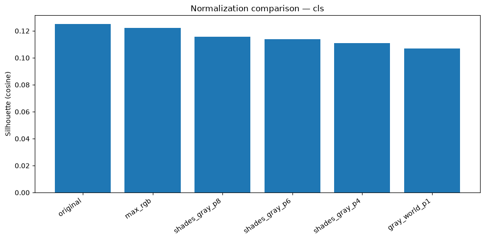

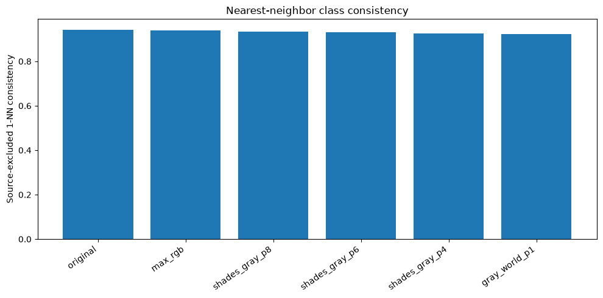

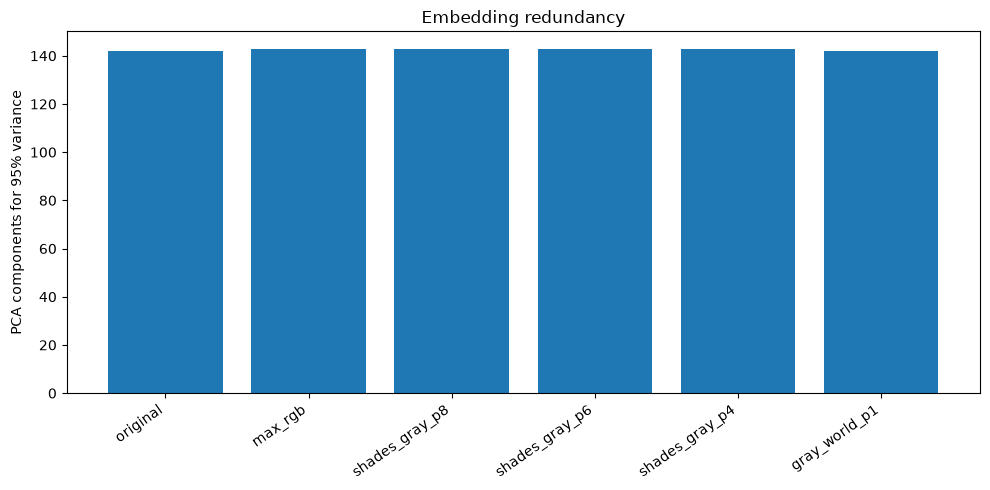

```python
best_mode_df = normalization_df[
    normalization_df["embedding_mode"]
    == BEST_EMBED_MODE
].copy()

best_mode_df = best_mode_df.sort_values(
    "silhouette_cosine",
    ascending=False,
)

plt.figure(figsize=(10, 5))
plt.bar(
    best_mode_df["normalization"],
    best_mode_df["silhouette_cosine"],
)
plt.xticks(rotation=35, ha="right")
plt.ylabel("Silhouette (cosine)")
plt.title(
    f"Normalization comparison — "
    f"{BEST_EMBED_MODE}"
)
plt.tight_layout()
plt.show()

plt.figure(figsize=(10, 5))
plt.bar(
    best_mode_df["normalization"],
    best_mode_df["knn1_excl_same_image"],
)
plt.xticks(rotation=35, ha="right")
plt.ylabel("Source-excluded 1-NN consistency")
plt.title("Nearest-neighbor class consistency")
plt.tight_layout()
plt.show()

plt.figure(figsize=(10, 5))
plt.bar(
    best_mode_df["normalization"],
    best_mode_df["pca_components_95"],
)
plt.xticks(rotation=35, ha="right")
plt.ylabel("PCA components for 95% variance")
plt.title("Embedding redundancy")
plt.tight_layout()
plt.show()
```

## 19. PCA: Original vs best preprocessing

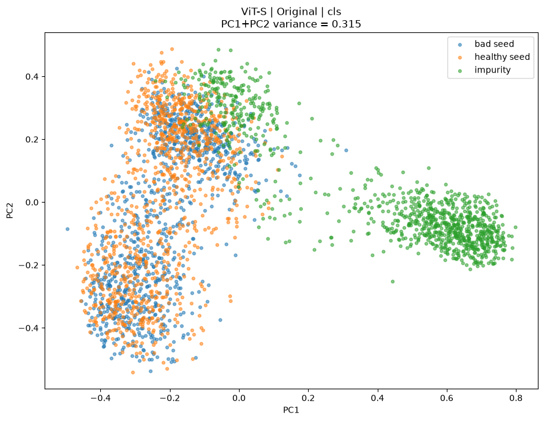

```python
plot_embedding_pca(
    normalization_embeddings[
        "original"
    ][BEST_EMBED_MODE],
    meta_eval_df,
    title=(
        f"ViT-S | Original | "
        f"{BEST_EMBED_MODE}"
    ),
)

if BEST_NORMALIZATION != "original":
    plot_embedding_pca(
        normalization_embeddings[
            BEST_NORMALIZATION
        ][BEST_EMBED_MODE],
        meta_eval_df,
        title=(
            f"ViT-S | "
            f"{BEST_NORMALIZATION} | "
            f"{BEST_EMBED_MODE}"
        ),
    )
```

## 20. PCA cumulative variance

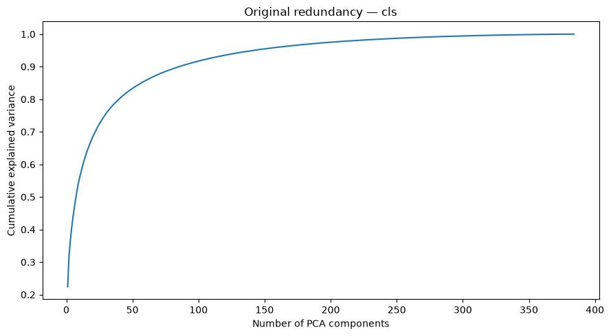

```python
def plot_cumulative_pca(
    embeddings: np.ndarray,
    title: str,
):
    _, explained_ratio = (
        feature_redundancy_metrics(
            embeddings
        )
    )

    cumulative = np.cumsum(
        explained_ratio
    )

    plt.figure(figsize=(9, 5))

    plt.plot(
        np.arange(
            1,
            len(cumulative) + 1,
        ),
        cumulative,
    )

    plt.xlabel("Number of PCA components")
    plt.ylabel("Cumulative explained variance")
    plt.title(title)
    plt.tight_layout()
    plt.show()


plot_cumulative_pca(
    normalization_embeddings[
        "original"
    ][BEST_EMBED_MODE],
    title=(
        f"Original redundancy — "
        f"{BEST_EMBED_MODE}"
    ),
)

if BEST_NORMALIZATION != "original":
    plot_cumulative_pca(
        normalization_embeddings[
            BEST_NORMALIZATION
        ][BEST_EMBED_MODE],
        title=(
            f"{BEST_NORMALIZATION} redundancy — "
            f"{BEST_EMBED_MODE}"
        ),
    )
```

## 21. Stage B — Robustness helpers

```python
def same_instance_cosine(
    reference: np.ndarray,
    current: np.ndarray,
):
    reference_n = l2_normalize_rows(
        reference.astype(np.float32)
    )

    current_n = l2_normalize_rows(
        current.astype(np.float32)
    )

    similarities = np.sum(
        reference_n * current_n,
        axis=1,
    )

    return {
        "embedding_stability_mean": float(
            np.mean(similarities)
        ),
        "embedding_stability_median": float(
            np.median(similarities)
        ),
        "embedding_stability_p05": float(
            np.quantile(
                similarities,
                0.05,
            )
        ),
        "embedding_stability_p01": float(
            np.quantile(
                similarities,
                0.01,
            )
        ),
    }


def mean_class_centroid_drift(
    reference: np.ndarray,
    current: np.ndarray,
    labels: np.ndarray,
):
    reference_n = l2_normalize_rows(
        reference.astype(np.float32)
    )

    current_n = l2_normalize_rows(
        current.astype(np.float32)
    )

    reference_centroids = class_centroids(
        reference_n,
        labels,
    )

    current_centroids = class_centroids(
        current_n,
        labels,
    )

    drifts = []

    for class_id in sorted(
        reference_centroids.keys()
    ):
        similarity = float(
            np.dot(
                reference_centroids[class_id],
                current_centroids[class_id],
            )
        )

        drifts.append(
            1.0 - similarity
        )

    return float(
        np.mean(drifts)
    )


original_spec = get_normalization_spec(
    "original"
)

best_spec = get_normalization_spec(
    BEST_NORMALIZATION
)

ROBUSTNESS_NORMALIZATIONS = [
    original_spec
]

if BEST_NORMALIZATION != "original":
    ROBUSTNESS_NORMALIZATIONS.append(
        best_spec
    )

print(
    "Robustness preprocessing:",
    [
        spec["name"]
        for spec
        in ROBUSTNESS_NORMALIZATIONS
    ],
)
```

```
Robustness preprocessing: ['original']
```

## 22. Run full ViT-S robustness matrix

```python
robustness_rows = []
robustness_embeddings = {}

labels_full = meta_eval_df[
    "class_id"
].to_numpy()

for normalization_spec in ROBUSTNESS_NORMALIZATIONS:
    normalization_name = (
        normalization_spec["name"]
    )

    reference = normalization_embeddings[
        normalization_name
    ][BEST_EMBED_MODE]

    for perturbation_spec in ROBUSTNESS_SPECS:
        perturbation_name = (
            perturbation_spec["name"]
        )

        if perturbation_name == "clean":
            result = normalization_embeddings[
                normalization_name
            ]
        else:
            result = extract_embeddings(
                model=vit_s_model,
                model_key="vit_s14",
                normalization_spec=normalization_spec,
                perturbation_spec=perturbation_spec,
                initial_batch_size=MODEL_CONFIGS[
                    "vit_s14"
                ]["initial_batch_size"],
            )

        current = result[
            BEST_EMBED_MODE
        ]

        robustness_embeddings[
            (
                normalization_name,
                perturbation_name,
            )
        ] = result

        stability = same_instance_cosine(
            reference,
            current,
        )

        separation, _ = separation_metrics(
            current,
            meta_eval_df,
        )

        centroid_drift = (
            mean_class_centroid_drift(
                reference,
                current,
                labels_full,
            )
        )

        robustness_rows.append({
            "model": "vit_s14",
            "normalization": normalization_name,
            "embedding_mode": BEST_EMBED_MODE,
            "perturbation": perturbation_name,
            **stability,
            **separation,
            "mean_class_centroid_drift": centroid_drift,
            "elapsed_sec": result["elapsed_sec"],
            "grains_per_sec": result["grains_per_sec"],
            "peak_gpu_mb": result["peak_gpu_mb"],
        })

robustness_df = pd.DataFrame(
    robustness_rows
)

robustness_path = (
    RESULTS_DIR
    / "robustness_vit_s.csv"
)

robustness_df.to_csv(
    robustness_path,
    index=False,
)

display(
    robustness_df.sort_values(
        [
            "normalization",
            "embedding_stability_mean",
        ],
        ascending=[True, True],
    )
)

print("Saved:", robustness_path)
```

```
vit_s14 | original | blur_strong | bs=32: 100%|██████████| 94/94 [01:45<00:00,  1.12s/it]
vit_s14 | original | noise_mild | bs=32: 100%|██████████| 94/94 [01:48<00:00,  1.15s/it]
vit_s14 | original | noise_strong | bs=32: 100%|██████████| 94/94 [01:53<00:00,  1.21s/it]
vit_s14 | original | brightness_dark | bs=32: 100%|██████████| 94/94 [02:36<00:00,  1.66s/it]
vit_s14 | original | brightness_bright | bs=32: 100%|██████████| 94/94 [02:42<00:00,  1.73s/it]
vit_s14 | original | contrast_low | bs=32: 100%|██████████| 94/94 [02:51<00:00,  1.83s/it]
vit_s14 | original | contrast_high | bs=32: 100%|██████████| 94/94 [02:44<00:00,  1.75s/it]
vit_s14 | original | illumination_warm | bs=32: 100%|██████████| 94/94 [02:36<00:00,  1.66s/it]
vit_s14 | original | illumination_cool | bs=32: 100%|██████████| 94/94 [02:19<00:00,  1.48s/it]
vit_s14 | original | resolution_50pct | bs=32: 100%|██████████| 94/94 [02:41<00:00,  1.72s/it]
vit_s14 | original | resolution_25pct | bs=32: 100%|██████████| 94/94 [01:52<00:00,  1.20s/it]
```

|  | model | normalization | embedding_mode | perturbation | embedding_stability_mean | embedding_stability_median | embedding_stability_p05 | embedding_stability_p01 | silhouette_cosine | knn1_excl_same_image | knn5_purity_excl_same_image | mean_centroid_cosine | max_centroid_cosine | bad_healthy_centroid_cosine | pca2_explained_variance | majority_chance | mean_class_centroid_drift | elapsed_sec | grains_per_sec | peak_gpu_mb |
| --- | --- | --- | --- | --- | --- | --- | --- | --- | --- | --- | --- | --- | --- | --- | --- | --- | --- | --- | --- | --- |
| 2 | vit_s14 | original | cls | blur_strong | 0.709736 | 0.713068 | 0.562367 | 0.509316 | 0.107234 | 0.942333 | 0.915267 | 0.826484 | 0.939392 | 0.939392 | 0.241216 | 0.333333 | 1.731302e-01 | 105.151538 | 28.530253 | 768.542969 |
| 12 | vit_s14 | original | cls | resolution_25pct | 0.734543 | 0.742022 | 0.566075 | 0.490494 | 0.082218 | 0.938667 | 0.907267 | 0.866684 | 0.945617 | 0.945617 | 0.231414 | 0.333333 | 1.370256e-01 | 112.554967 | 26.653644 | 768.542969 |
| 4 | vit_s14 | original | cls | noise_strong | 0.838738 | 0.844519 | 0.737040 | 0.678859 | 0.098979 | 0.902333 | 0.874267 | 0.780870 | 0.969595 | 0.969595 | 0.298471 | 0.333333 | 9.770372e-02 | 113.970866 | 26.322516 | 768.542969 |
| 1 | vit_s14 | original | cls | blur_mild | 0.878023 | 0.884813 | 0.781104 | 0.720945 | 0.111919 | 0.944000 | 0.918000 | 0.767241 | 0.933745 | 0.933745 | 0.259041 | 0.333333 | 5.174712e-02 | 104.637914 | 28.670296 | 768.542969 |
| 11 | vit_s14 | original | cls | resolution_50pct | 0.906319 | 0.916765 | 0.808809 | 0.739592 | 0.115341 | 0.937333 | 0.917333 | 0.750909 | 0.936052 | 0.936052 | 0.268342 | 0.333333 | 2.716428e-02 | 161.834121 | 18.537500 | 768.542969 |
| 3 | vit_s14 | original | cls | noise_mild | 0.941674 | 0.947238 | 0.892206 | 0.854788 | 0.124371 | 0.921000 | 0.892200 | 0.707183 | 0.954245 | 0.954245 | 0.322221 | 0.333333 | 2.924097e-02 | 108.358717 | 27.685821 | 768.542969 |
| 10 | vit_s14 | original | cls | illumination_cool | 0.965558 | 0.968293 | 0.934915 | 0.909753 | 0.120005 | 0.938000 | 0.915067 | 0.702772 | 0.940296 | 0.940296 | 0.303943 | 0.333333 | 2.147792e-02 | 139.216855 | 21.549115 | 768.542969 |
| 9 | vit_s14 | original | cls | illumination_warm | 0.977833 | 0.980528 | 0.955223 | 0.936660 | 0.123594 | 0.933000 | 0.903000 | 0.692313 | 0.940485 | 0.940485 | 0.316280 | 0.333333 | 1.312860e-02 | 156.448707 | 19.175614 | 768.542969 |
| 6 | vit_s14 | original | cls | brightness_bright | 0.984672 | 0.989110 | 0.957052 | 0.928931 | 0.122708 | 0.947667 | 0.914667 | 0.684353 | 0.938365 | 0.938365 | 0.307584 | 0.333333 | 1.810153e-03 | 162.895543 | 18.416710 | 768.542969 |
| 5 | vit_s14 | original | cls | brightness_dark | 0.984844 | 0.987821 | 0.964765 | 0.940147 | 0.126910 | 0.942000 | 0.916600 | 0.677449 | 0.937150 | 0.937150 | 0.318849 | 0.333333 | 2.411445e-03 | 156.239624 | 19.201275 | 768.542969 |
| 8 | vit_s14 | original | cls | contrast_high | 0.992942 | 0.994311 | 0.983520 | 0.976193 | 0.123380 | 0.943333 | 0.913000 | 0.683277 | 0.939029 | 0.939029 | 0.304588 | 0.333333 | 2.153377e-03 | 164.046379 | 18.287511 | 768.542969 |
| 7 | vit_s14 | original | cls | contrast_low | 0.993987 | 0.994771 | 0.987704 | 0.981464 | 0.125982 | 0.943000 | 0.915600 | 0.681789 | 0.937123 | 0.937123 | 0.316406 | 0.333333 | 2.210538e-03 | 171.664375 | 17.475961 | 768.542969 |
| 0 | vit_s14 | original | cls | clean | 1.000000 | 1.000000 | 1.000000 | 1.000000 | 0.125265 | 0.943000 | 0.912800 | 0.680001 | 0.939087 | 0.939087 | 0.314762 | 0.333333 | -1.986821e-08 | 110.597488 | 27.125390 | 768.542969 |

```
Saved: C:\Users\alool\Desktop\Codes\Python\Test_RFDeter\notebooks_Test_DinoV2\dinov2_comprehensive_eval\results\robustness_vit_s.csv
```

## 23. Robustness plots

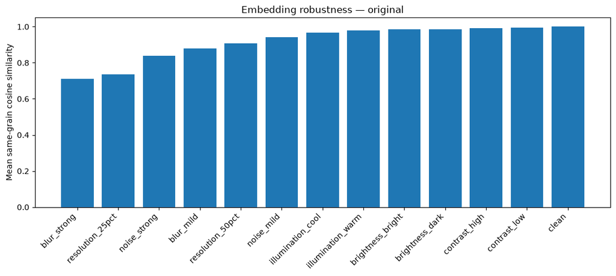

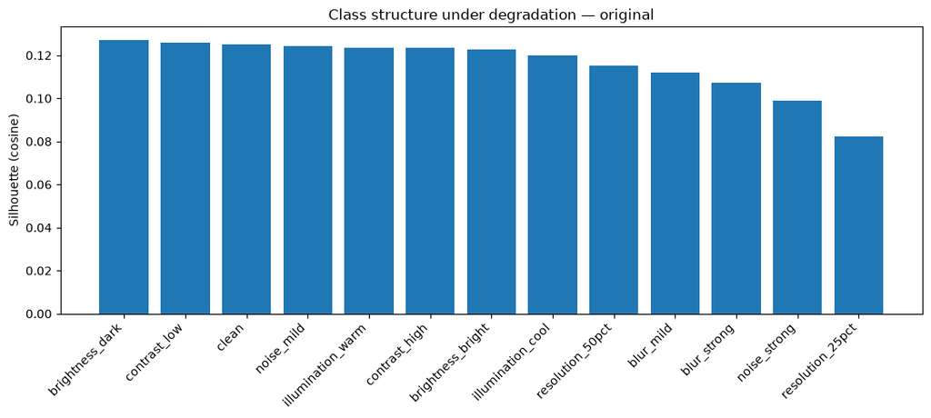

```python
for normalization_name, group in robustness_df.groupby(
    "normalization"
):
    group = group.sort_values(
        "embedding_stability_mean"
    )

    plt.figure(figsize=(11, 5))

    plt.bar(
        group["perturbation"],
        group["embedding_stability_mean"],
    )

    plt.xticks(
        rotation=45,
        ha="right",
    )

    plt.ylabel(
        "Mean same-grain cosine similarity"
    )

    plt.title(
        f"Embedding robustness — "
        f"{normalization_name}"
    )

    plt.tight_layout()
    plt.show()


for normalization_name, group in robustness_df.groupby(
    "normalization"
):
    group = group.sort_values(
        "silhouette_cosine",
        ascending=False,
    )

    plt.figure(figsize=(11, 5))

    plt.bar(
        group["perturbation"],
        group["silhouette_cosine"],
    )

    plt.xticks(
        rotation=45,
        ha="right",
    )

    plt.ylabel(
        "Silhouette (cosine)"
    )

    plt.title(
        f"Class structure under degradation — "
        f"{normalization_name}"
    )

    plt.tight_layout()
    plt.show()
```

## 24. Does color constancy improve robustness?

```python
if BEST_NORMALIZATION != "original":
    original_robustness = (
        robustness_df[
            robustness_df["normalization"]
            == "original"
        ]
        .set_index("perturbation")
    )

    normalized_robustness = (
        robustness_df[
            robustness_df["normalization"]
            == BEST_NORMALIZATION
        ]
        .set_index("perturbation")
    )

    common_conditions = (
        original_robustness.index
        .intersection(
            normalized_robustness.index
        )
    )

    robustness_delta_df = pd.DataFrame({
        "perturbation": common_conditions,
        "original_stability": (
            original_robustness.loc[
                common_conditions,
                "embedding_stability_mean",
            ].to_numpy()
        ),
        "normalized_stability": (
            normalized_robustness.loc[
                common_conditions,
                "embedding_stability_mean",
            ].to_numpy()
        ),
        "original_silhouette": (
            original_robustness.loc[
                common_conditions,
                "silhouette_cosine",
            ].to_numpy()
        ),
        "normalized_silhouette": (
            normalized_robustness.loc[
                common_conditions,
                "silhouette_cosine",
            ].to_numpy()
        ),
    })

    robustness_delta_df[
        "delta_stability"
    ] = (
        robustness_delta_df[
            "normalized_stability"
        ]
        - robustness_delta_df[
            "original_stability"
        ]
    )

    robustness_delta_df[
        "delta_silhouette"
    ] = (
        robustness_delta_df[
            "normalized_silhouette"
        ]
        - robustness_delta_df[
            "original_silhouette"
        ]
    )

    display(
        robustness_delta_df.sort_values(
            "delta_stability",
            ascending=False,
        )
    )

    robustness_delta_df.to_csv(
        RESULTS_DIR
        / "color_constancy_robustness_delta.csv",
        index=False,
    )

else:
    print(
        "Original preprocessing ranked best, "
        "so there is no second normalization pipeline."
    )
```

```
Original preprocessing ranked best, so there is no second normalization pipeline.
```

## 25. Stage C — ViT-S/14 vs ViT-B/14

```python
release_model(vit_s_model)

vit_b_model, vit_b_params = load_dino_model(
    "vit_b14"
)

print(
    f"ViT-B parameters: "
    f"{vit_b_params / 1e6:.2f}M"
)
```

```
Using cache found in C:\Users\alool/.cache\torch\hub\facebookresearch_dinov2_main
```

```
Downloading: "https://dl.fbaipublicfiles.com/dinov2/dinov2_vitb14/dinov2_vitb14_pretrain.pth" to C:\Users\alool/.cache\torch\hub\checkpoints\dinov2_vitb14_pretrain.pth
```

```
ViT-B parameters: 86.58M
```

## 26. ViT-B clean original + best normalization

```python
vit_b_rows = []
vit_b_clean_results = {}

vit_b_normalizations = [
    get_normalization_spec("original")
]

if BEST_NORMALIZATION != "original":
    vit_b_normalizations.append(
        get_normalization_spec(
            BEST_NORMALIZATION
        )
    )

for normalization_spec in vit_b_normalizations:
    result = extract_embeddings(
        model=vit_b_model,
        model_key="vit_b14",
        normalization_spec=normalization_spec,
        perturbation_spec=clean_spec,
        initial_batch_size=MODEL_CONFIGS[
            "vit_b14"
        ]["initial_batch_size"],
    )

    vit_b_clean_results[
        normalization_spec["name"]
    ] = result

    for embedding_mode in EMBEDDING_MODES:
        embeddings = result[
            embedding_mode
        ]

        separation, _ = separation_metrics(
            embeddings,
            meta_eval_df,
        )

        redundancy, _ = feature_redundancy_metrics(
            embeddings
        )

        vit_b_rows.append({
            "model": "vit_b14",
            "normalization": normalization_spec["name"],
            "embedding_mode": embedding_mode,
            **separation,
            **redundancy,
            "elapsed_sec": result["elapsed_sec"],
            "grains_per_sec": result["grains_per_sec"],
            "peak_gpu_mb": result["peak_gpu_mb"],
            "batch_size": result["batch_size"],
        })

vit_b_df = pd.DataFrame(
    vit_b_rows
)

vit_b_path = (
    RESULTS_DIR
    / "vit_b_clean_comparison.csv"
)

vit_b_df.to_csv(
    vit_b_path,
    index=False,
)

display(
    vit_b_df.sort_values(
        [
            "silhouette_cosine",
            "knn1_excl_same_image",
        ],
        ascending=[False, False],
    )
)

print("Saved:", vit_b_path)
```

|  | model | normalization | embedding_mode | silhouette_cosine | knn1_excl_same_image | knn5_purity_excl_same_image | mean_centroid_cosine | max_centroid_cosine | bad_healthy_centroid_cosine | pca2_explained_variance | ... | pca_components_99 | effective_rank | participation_ratio | mean_abs_feature_corr | fraction_abs_corr_ge_090 | fraction_abs_corr_ge_095 | elapsed_sec | grains_per_sec | peak_gpu_mb | batch_size |
| --- | --- | --- | --- | --- | --- | --- | --- | --- | --- | --- | --- | --- | --- | --- | --- | --- | --- | --- | --- | --- | --- |
| 0 | vit_b14 | original | cls | 0.118306 | 0.940667 | 0.917400 | 0.645881 | 0.924747 | 0.924747 | 0.263242 | ... | 527 | 77.236588 | 18.541742 | 0.153692 | 0.000000e+00 | 0.0 | 224.476325 | 13.364438 | 736.116211 | 8 |
| 2 | vit_b14 | original | cls_mean_concat | 0.115496 | 0.942333 | 0.915933 | 0.740145 | 0.945132 | 0.945132 | 0.261289 | ... | 627 | 80.359085 | 18.654446 | 0.158796 | 8.482628e-07 | 0.0 | 224.476325 | 13.364438 | 736.116211 | 8 |
| 1 | vit_b14 | original | mean_patch | 0.085188 | 0.918000 | 0.877533 | 0.917734 | 0.986096 | 0.986096 | 0.313895 | ... | 437 | 52.285416 | 14.938737 | 0.177210 | 0.000000e+00 | 0.0 | 224.476325 | 13.364438 | 736.116211 | 8 |

3 rows × 25 columns

```
Saved: C:\Users\alool\Desktop\Codes\Python\Test_RFDeter\notebooks_Test_DinoV2\dinov2_comprehensive_eval\results\vit_b_clean_comparison.csv
```

## 27. Optional complete ViT-B robustness

```python
vit_b_robustness_df = pd.DataFrame()

if RUN_VITB_ALL_ROBUSTNESS:
    rows = []

    for normalization_spec in ROBUSTNESS_NORMALIZATIONS:
        normalization_name = (
            normalization_spec["name"]
        )

        clean_result = (
            vit_b_clean_results[
                normalization_name
            ]
        )

        reference = clean_result[
            BEST_EMBED_MODE
        ]

        for perturbation_spec in ROBUSTNESS_SPECS:
            if perturbation_spec["name"] == "clean":
                result = clean_result
            else:
                result = extract_embeddings(
                    model=vit_b_model,
                    model_key="vit_b14",
                    normalization_spec=normalization_spec,
                    perturbation_spec=perturbation_spec,
                    initial_batch_size=MODEL_CONFIGS[
                        "vit_b14"
                    ]["initial_batch_size"],
                )

            current = result[
                BEST_EMBED_MODE
            ]

            stability = same_instance_cosine(
                reference,
                current,
            )

            separation, _ = separation_metrics(
                current,
                meta_eval_df,
            )

            drift = mean_class_centroid_drift(
                reference,
                current,
                labels_full,
            )

            rows.append({
                "model": "vit_b14",
                "normalization": normalization_name,
                "embedding_mode": BEST_EMBED_MODE,
                "perturbation": perturbation_spec["name"],
                **stability,
                **separation,
                "mean_class_centroid_drift": drift,
                "elapsed_sec": result["elapsed_sec"],
                "grains_per_sec": result["grains_per_sec"],
                "peak_gpu_mb": result["peak_gpu_mb"],
            })

    vit_b_robustness_df = pd.DataFrame(
        rows
    )

    vit_b_robustness_df.to_csv(
        RESULTS_DIR
        / "robustness_vit_b.csv",
        index=False,
    )

    display(
        vit_b_robustness_df
    )

else:
    print(
        "Full ViT-B robustness skipped. "
        "Set RUN_VITB_ALL_ROBUSTNESS=True "
        "to run the expensive complete matrix."
    )
```

```
Full ViT-B robustness skipped. Set RUN_VITB_ALL_ROBUSTNESS=True to run the expensive complete matrix.
```

## 28. Fair ViT-S vs ViT-B comparison

```python
comparison_rows = []

conditions = ["original"]

if BEST_NORMALIZATION != "original":
    conditions.append(
        BEST_NORMALIZATION
    )

for normalization_name in conditions:
    vit_s_row = normalization_df[
        (
            normalization_df["normalization"]
            == normalization_name
        )
        & (
            normalization_df["embedding_mode"]
            == BEST_EMBED_MODE
        )
    ].iloc[0]

    vit_b_row = vit_b_df[
        (
            vit_b_df["normalization"]
            == normalization_name
        )
        & (
            vit_b_df["embedding_mode"]
            == BEST_EMBED_MODE
        )
    ].iloc[0]

    comparison_rows.append({
        "model": "vit_s14",
        "parameters_m": vit_s_params / 1e6,
        "normalization": normalization_name,
        "embedding_mode": BEST_EMBED_MODE,
        "embedding_dim": vit_s_row["embedding_dim"],
        "silhouette_cosine": vit_s_row["silhouette_cosine"],
        "knn1_excl_same_image": vit_s_row["knn1_excl_same_image"],
        "knn5_purity_excl_same_image": vit_s_row["knn5_purity_excl_same_image"],
        "mean_centroid_cosine": vit_s_row["mean_centroid_cosine"],
        "pca_components_95": vit_s_row["pca_components_95"],
        "effective_rank": vit_s_row["effective_rank"],
        "grains_per_sec": vit_s_row["grains_per_sec"],
        "peak_gpu_mb": vit_s_row["peak_gpu_mb"],
    })

    comparison_rows.append({
        "model": "vit_b14",
        "parameters_m": vit_b_params / 1e6,
        "normalization": normalization_name,
        "embedding_mode": BEST_EMBED_MODE,
        "embedding_dim": vit_b_row["embedding_dim"],
        "silhouette_cosine": vit_b_row["silhouette_cosine"],
        "knn1_excl_same_image": vit_b_row["knn1_excl_same_image"],
        "knn5_purity_excl_same_image": vit_b_row["knn5_purity_excl_same_image"],
        "mean_centroid_cosine": vit_b_row["mean_centroid_cosine"],
        "pca_components_95": vit_b_row["pca_components_95"],
        "effective_rank": vit_b_row["effective_rank"],
        "grains_per_sec": vit_b_row["grains_per_sec"],
        "peak_gpu_mb": vit_b_row["peak_gpu_mb"],
    })

model_comparison_df = pd.DataFrame(
    comparison_rows
)

display(
    model_comparison_df
)

model_comparison_df.to_csv(
    RESULTS_DIR
    / "vit_s_vs_vit_b.csv",
    index=False,
)
```

|  | model | parameters_m | normalization | embedding_mode | embedding_dim | silhouette_cosine | knn1_excl_same_image | knn5_purity_excl_same_image | mean_centroid_cosine | pca_components_95 | effective_rank | grains_per_sec | peak_gpu_mb |
| --- | --- | --- | --- | --- | --- | --- | --- | --- | --- | --- | --- | --- | --- |
| 0 | vit_s14 | 22.056576 | original | cls | 384 | 0.125265 | 0.943000 | 0.9128 | 0.680001 | 142 | 49.365093 | 27.125390 | 768.542969 |
| 1 | vit_b14 | 86.580480 | original | cls | 768 | 0.118306 | 0.940667 | 0.9174 | 0.645881 | 273 | 77.236588 | 13.364438 | 736.116211 |

## 29. Model-size trade-off plots

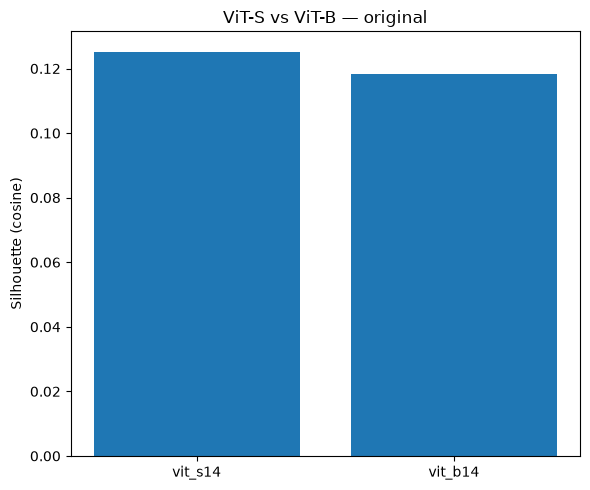

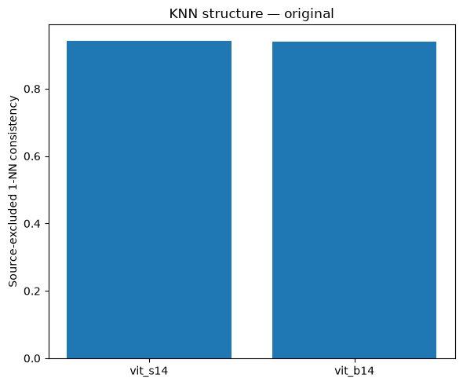

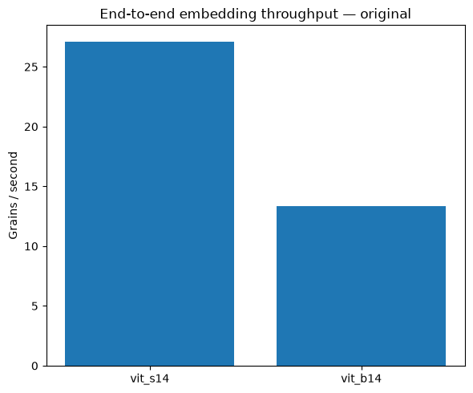

```python
for normalization_name, group in model_comparison_df.groupby(
    "normalization"
):
    plt.figure(figsize=(6, 5))

    plt.bar(
        group["model"],
        group["silhouette_cosine"],
    )

    plt.ylabel(
        "Silhouette (cosine)"
    )

    plt.title(
        f"ViT-S vs ViT-B — "
        f"{normalization_name}"
    )

    plt.tight_layout()
    plt.show()

    plt.figure(figsize=(6, 5))

    plt.bar(
        group["model"],
        group["knn1_excl_same_image"],
    )

    plt.ylabel(
        "Source-excluded 1-NN consistency"
    )

    plt.title(
        f"KNN structure — "
        f"{normalization_name}"
    )

    plt.tight_layout()
    plt.show()

    plt.figure(figsize=(6, 5))

    plt.bar(
        group["model"],
        group["grains_per_sec"],
    )

    plt.ylabel(
        "Grains / second"
    )

    plt.title(
        f"End-to-end embedding throughput — "
        f"{normalization_name}"
    )

    plt.tight_layout()
    plt.show()
```

## 30. Rank the best ViT-B configuration

```python
vit_b_rank = vit_b_df.copy()

vit_b_rank["rank_silhouette"] = (
    vit_b_rank["silhouette_cosine"]
    .rank(
        ascending=False,
        method="min",
    )
)

vit_b_rank["rank_knn1"] = (
    vit_b_rank["knn1_excl_same_image"]
    .rank(
        ascending=False,
        method="min",
    )
)

vit_b_rank["rank_knn5"] = (
    vit_b_rank["knn5_purity_excl_same_image"]
    .rank(
        ascending=False,
        method="min",
    )
)

vit_b_rank["rank_centroid"] = (
    vit_b_rank["mean_centroid_cosine"]
    .rank(
        ascending=True,
        method="min",
    )
)

vit_b_rank["selection_rank_sum"] = (
    vit_b_rank["rank_silhouette"]
    + vit_b_rank["rank_knn1"]
    + vit_b_rank["rank_knn5"]
    + vit_b_rank["rank_centroid"]
)

vit_b_rank = vit_b_rank.sort_values(
    [
        "selection_rank_sum",
        "silhouette_cosine",
    ],
    ascending=[True, False],
).reset_index(drop=True)

display(
    vit_b_rank[
        [
            "normalization",
            "embedding_mode",
            "silhouette_cosine",
            "knn1_excl_same_image",
            "knn5_purity_excl_same_image",
            "mean_centroid_cosine",
            "pca_components_95",
            "effective_rank",
            "selection_rank_sum",
        ]
    ]
)
```

|  | normalization | embedding_mode | silhouette_cosine | knn1_excl_same_image | knn5_purity_excl_same_image | mean_centroid_cosine | pca_components_95 | effective_rank | selection_rank_sum |
| --- | --- | --- | --- | --- | --- | --- | --- | --- | --- |
| 0 | original | cls | 0.118306 | 0.940667 | 0.917400 | 0.645881 | 273 | 77.236588 | 5.0 |
| 1 | original | cls_mean_concat | 0.115496 | 0.942333 | 0.915933 | 0.740145 | 297 | 80.359085 | 7.0 |
| 2 | original | mean_patch | 0.085188 | 0.918000 | 0.877533 | 0.917734 | 191 | 52.285416 | 12.0 |

## 31. Class-wise robustness

```python
def classwise_embedding_stability(
    reference: np.ndarray,
    current: np.ndarray,
    meta_df: pd.DataFrame,
):
    reference_n = l2_normalize_rows(
        reference.astype(np.float32)
    )

    current_n = l2_normalize_rows(
        current.astype(np.float32)
    )

    similarities = np.sum(
        reference_n * current_n,
        axis=1,
    )

    temp = meta_df[
        [
            "class_id",
            "class_name",
        ]
    ].copy()

    temp["same_instance_cosine"] = (
        similarities
    )

    return (
        temp.groupby(
            [
                "class_id",
                "class_name",
            ]
        )["same_instance_cosine"]
        .agg(
            [
                "mean",
                "median",
                "std",
                "count",
            ]
        )
        .reset_index()
    )


classwise_rows = []

for normalization_spec in ROBUSTNESS_NORMALIZATIONS:
    normalization_name = normalization_spec[
        "name"
    ]

    reference = normalization_embeddings[
        normalization_name
    ][BEST_EMBED_MODE]

    for perturbation_spec in ROBUSTNESS_SPECS:
        perturbation_name = perturbation_spec[
            "name"
        ]

        result = robustness_embeddings[
            (
                normalization_name,
                perturbation_name,
            )
        ]

        current = result[
            BEST_EMBED_MODE
        ]

        temp = classwise_embedding_stability(
            reference,
            current,
            meta_eval_df,
        )

        temp["normalization"] = (
            normalization_name
        )

        temp["perturbation"] = (
            perturbation_name
        )

        classwise_rows.append(
            temp
        )

classwise_robustness_df = pd.concat(
    classwise_rows,
    ignore_index=True,
)

display(
    classwise_robustness_df
)

classwise_robustness_df.to_csv(
    RESULTS_DIR
    / "classwise_robustness_vit_s.csv",
    index=False,
)
```

|  | class_id | class_name | mean | median | std | count | normalization | perturbation |
| --- | --- | --- | --- | --- | --- | --- | --- | --- |
| 0 | 0 | bad seed | 1.000000 | 1.000000 | 7.520566e-08 | 1000 | original | clean |
| 1 | 1 | healthy seed | 1.000000 | 1.000000 | 7.123851e-08 | 1000 | original | clean |
| 2 | 2 | impurity | 1.000000 | 1.000000 | 7.208066e-08 | 1000 | original | clean |
| 3 | 0 | bad seed | 0.869769 | 0.874454 | 4.607615e-02 | 1000 | original | blur_mild |
| 4 | 1 | healthy seed | 0.859797 | 0.866191 | 5.803237e-02 | 1000 | original | blur_mild |
| 5 | 2 | impurity | 0.904502 | 0.914303 | 4.720614e-02 | 1000 | original | blur_mild |
| 6 | 0 | bad seed | 0.697144 | 0.697338 | 8.041468e-02 | 1000 | original | blur_strong |
| 7 | 1 | healthy seed | 0.701609 | 0.706295 | 8.684190e-02 | 1000 | original | blur_strong |
| 8 | 2 | impurity | 0.730456 | 0.735250 | 8.350728e-02 | 1000 | original | blur_strong |
| 9 | 0 | bad seed | 0.942591 | 0.946949 | 2.330720e-02 | 1000 | original | noise_mild |
| 10 | 1 | healthy seed | 0.932802 | 0.938263 | 3.213860e-02 | 1000 | original | noise_mild |
| 11 | 2 | impurity | 0.949630 | 0.952632 | 1.978532e-02 | 1000 | original | noise_mild |
| 12 | 0 | bad seed | 0.829591 | 0.835709 | 4.660054e-02 | 1000 | original | noise_strong |
| 13 | 1 | healthy seed | 0.821406 | 0.827940 | 6.240032e-02 | 1000 | original | noise_strong |
| 14 | 2 | impurity | 0.865216 | 0.871999 | 4.692626e-02 | 1000 | original | noise_strong |
| 15 | 0 | bad seed | 0.986150 | 0.988022 | 8.404506e-03 | 1000 | original | brightness_dark |
| 16 | 1 | healthy seed | 0.981346 | 0.985528 | 1.466354e-02 | 1000 | original | brightness_dark |
| 17 | 2 | impurity | 0.987035 | 0.989077 | 8.140543e-03 | 1000 | original | brightness_dark |
| 18 | 0 | bad seed | 0.985755 | 0.988418 | 9.481711e-03 | 1000 | original | brightness_bright |
| 19 | 1 | healthy seed | 0.978290 | 0.983996 | 1.639814e-02 | 1000 | original | brightness_bright |
| 20 | 2 | impurity | 0.989972 | 0.992959 | 1.108868e-02 | 1000 | original | brightness_bright |
| 21 | 0 | bad seed | 0.994575 | 0.995273 | 3.286492e-03 | 1000 | original | contrast_low |
| 22 | 1 | healthy seed | 0.993025 | 0.994068 | 4.170205e-03 | 1000 | original | contrast_low |
| 23 | 2 | impurity | 0.994361 | 0.994813 | 3.036752e-03 | 1000 | original | contrast_low |
| 24 | 0 | bad seed | 0.993769 | 0.994781 | 3.932220e-03 | 1000 | original | contrast_high |
| 25 | 1 | healthy seed | 0.993005 | 0.994112 | 4.257477e-03 | 1000 | original | contrast_high |
| 26 | 2 | impurity | 0.992051 | 0.993887 | 5.897131e-03 | 1000 | original | contrast_high |
| 27 | 0 | bad seed | 0.979187 | 0.981260 | 9.878739e-03 | 1000 | original | illumination_warm |
| 28 | 1 | healthy seed | 0.979100 | 0.981755 | 1.267517e-02 | 1000 | original | illumination_warm |
| 29 | 2 | impurity | 0.975212 | 0.977945 | 1.301732e-02 | 1000 | original | illumination_warm |
| 30 | 0 | bad seed | 0.963420 | 0.965819 | 1.536082e-02 | 1000 | original | illumination_cool |
| 31 | 1 | healthy seed | 0.967836 | 0.971852 | 1.719162e-02 | 1000 | original | illumination_cool |
| 32 | 2 | impurity | 0.965419 | 0.968374 | 1.648483e-02 | 1000 | original | illumination_cool |
| 33 | 0 | bad seed | 0.893710 | 0.899637 | 4.760977e-02 | 1000 | original | resolution_50pct |
| 34 | 1 | healthy seed | 0.893526 | 0.904623 | 6.097443e-02 | 1000 | original | resolution_50pct |
| 35 | 2 | impurity | 0.931721 | 0.940266 | 4.003761e-02 | 1000 | original | resolution_50pct |
| 36 | 0 | bad seed | 0.722195 | 0.723995 | 9.111685e-02 | 1000 | original | resolution_25pct |
| 37 | 1 | healthy seed | 0.715691 | 0.720343 | 9.890608e-02 | 1000 | original | resolution_25pct |
| 38 | 2 | impurity | 0.765742 | 0.771774 | 8.269308e-02 | 1000 | original | resolution_25pct |

## 32. Final evidence summary

```python
best_vit_s = ranking_df.iloc[0]
best_vit_b = vit_b_rank.iloc[0]

robustness_nonclean = robustness_df[
    robustness_df["perturbation"]
    != "clean"
].copy()

worst_cases = []

for normalization_name, group in robustness_nonclean.groupby(
    "normalization"
):
    worst = group.sort_values(
        "embedding_stability_mean"
    ).iloc[0]

    worst_cases.append({
        "normalization": normalization_name,
        "worst_perturbation": str(
            worst["perturbation"]
        ),
        "mean_embedding_stability": float(
            worst["embedding_stability_mean"]
        ),
        "silhouette": float(
            worst["silhouette_cosine"]
        ),
    })

summary = {
    "dataset": str(DATASET_DIR),
    "subset_size": int(
        len(subset_df)
    ),
    "resize_mode": RESIZE_MODE,
    "classes": {
        int(key): str(value)
        for key, value
        in CLASS_NAMES.items()
    },
    "best_vit_s": {
        "normalization": str(
            best_vit_s["normalization"]
        ),
        "embedding_mode": str(
            best_vit_s["embedding_mode"]
        ),
        "silhouette_cosine": float(
            best_vit_s["silhouette_cosine"]
        ),
        "knn1_excl_same_image": float(
            best_vit_s["knn1_excl_same_image"]
        ),
        "knn5_purity_excl_same_image": float(
            best_vit_s[
                "knn5_purity_excl_same_image"
            ]
        ),
        "mean_centroid_cosine": float(
            best_vit_s[
                "mean_centroid_cosine"
            ]
        ),
        "pca_components_95": int(
            best_vit_s[
                "pca_components_95"
            ]
        ),
        "effective_rank": float(
            best_vit_s[
                "effective_rank"
            ]
        ),
    },
    "best_vit_b": {
        "normalization": str(
            best_vit_b["normalization"]
        ),
        "embedding_mode": str(
            best_vit_b["embedding_mode"]
        ),
        "silhouette_cosine": float(
            best_vit_b["silhouette_cosine"]
        ),
        "knn1_excl_same_image": float(
            best_vit_b["knn1_excl_same_image"]
        ),
        "knn5_purity_excl_same_image": float(
            best_vit_b[
                "knn5_purity_excl_same_image"
            ]
        ),
        "mean_centroid_cosine": float(
            best_vit_b[
                "mean_centroid_cosine"
            ]
        ),
    },
    "worst_robustness_cases": worst_cases,
}

summary_path = (
    RESULTS_DIR
    / "final_summary.json"
)

summary_path.write_text(
    json.dumps(
        summary,
        indent=2,
    ),
    encoding="utf-8",
)

print(
    json.dumps(
        summary,
        indent=2,
    )
)

print(
    "\nSaved:",
    summary_path,
)
```

```
{
  "dataset": "C:\\Users\\alool\\Desktop\\Codes\\Python\\Test_RFDeter\\wheatdecv1_seg",
  "subset_size": 3000,
  "resize_mode": "aspect_pad",
  "classes": {
    "0": "bad seed",
    "1": "healthy seed",
    "2": "impurity"
  },
  "best_vit_s": {
    "normalization": "original",
    "embedding_mode": "cls",
    "silhouette_cosine": 0.12526515126228333,
    "knn1_excl_same_image": 0.943,
    "knn5_purity_excl_same_image": 0.9127999999999998,
    "mean_centroid_cosine": 0.680000921090444,
    "pca_components_95": 142,
    "effective_rank": 49.36509323120117
  },
  "best_vit_b": {
    "normalization": "original",
    "embedding_mode": "cls",
    "silhouette_cosine": 0.1183062344789505,
    "knn1_excl_same_image": 0.9406666666666667,
    "knn5_purity_excl_same_image": 0.9174,
    "mean_centroid_cosine": 0.645880937576294
  },
  "worst_robustness_cases": [
    {
      "normalization": "original",
      "worst_perturbation": "blur_strong",
      "mean_embedding_stability": 0.7097363471984863,
      "silhouette": 0.10723387449979782
    }
  ]
}

Saved: C:\Users\alool\Desktop\Codes\Python\Test_RFDeter\notebooks_Test_DinoV2\dinov2_comprehensive_eval\results\final_summary.json
```

## 33. Auto-generated conclusion helper

```python
best_vit_s = ranking_df.iloc[0]
best_vit_b = vit_b_rank.iloc[0]

original_same_mode = ranking_df[
    (
        ranking_df["normalization"]
        == "original"
    )
    & (
        ranking_df["embedding_mode"]
        == BEST_EMBED_MODE
    )
].iloc[0]

print("=== NORMALIZATION ===")

if BEST_NORMALIZATION == "original":
    print(
        "Original preprocessing ranked best "
        "for ViT-S under the selected metrics."
    )
else:
    print(
        f"{BEST_NORMALIZATION} ranked above "
        f"Original using {BEST_EMBED_MODE}."
    )

    print(
        "Silhouette:",
        f"{original_same_mode['silhouette_cosine']:.4f}",
        "->",
        f"{best_vit_s['silhouette_cosine']:.4f}",
    )

    print(
        "Source-excluded 1-NN:",
        f"{original_same_mode['knn1_excl_same_image']:.4f}",
        "->",
        f"{best_vit_s['knn1_excl_same_image']:.4f}",
    )

print("\n=== REDUNDANCY ===")

print(
    f"Embedding dimension = "
    f"{int(best_vit_s['embedding_dim'])}"
)

print(
    f"95% PCA variance = "
    f"{int(best_vit_s['pca_components_95'])} "
    f"components"
)

print(
    f"Effective rank = "
    f"{best_vit_s['effective_rank']:.2f}"
)

print("\n=== ROBUSTNESS ===")

for item in worst_cases:
    print(
        f"{item['normalization']}: "
        f"worst = {item['worst_perturbation']} | "
        f"stability = "
        f"{item['mean_embedding_stability']:.4f} | "
        f"silhouette = "
        f"{item['silhouette']:.4f}"
    )

print("\n=== MODEL SIZE ===")

print(
    f"ViT-S params = "
    f"{vit_s_params / 1e6:.2f}M"
)

print(
    f"ViT-B params = "
    f"{vit_b_params / 1e6:.2f}M"
)

print(
    f"Best ViT-S silhouette = "
    f"{best_vit_s['silhouette_cosine']:.4f}"
)

print(
    f"Best ViT-B silhouette = "
    f"{best_vit_b['silhouette_cosine']:.4f}"
)

print("\n=== NEXT DECISION ===")

print(
    "If the pretrained embeddings show useful class structure "
    "and acceptable robustness, continue. "
    "Only consider fine-tuning if the representation is promising "
    "but separation is still insufficient."
)
```

```
=== NORMALIZATION ===
Original preprocessing ranked best for ViT-S under the selected metrics.

=== REDUNDANCY ===
Embedding dimension = 384
95% PCA variance = 142 components
Effective rank = 49.37

=== ROBUSTNESS ===
original: worst = blur_strong | stability = 0.7097 | silhouette = 0.1072

=== MODEL SIZE ===
ViT-S params = 22.06M
ViT-B params = 86.58M
Best ViT-S silhouette = 0.1253
Best ViT-B silhouette = 0.1183

=== NEXT DECISION ===
If the pretrained embeddings show useful class structure and acceptable robustness, continue. Only consider fine-tuning if the representation is promising but separation is still insufficient.
```

## 34. How to interpret the results

### Normalization

A normalization method is useful only if it improves class structure **without** damaging information that matters for grain quality.

Focus on:

- higher `silhouette_cosine`,
- higher `knn1_excl_same_image`,
- higher `knn5_purity_excl_same_image`,
- lower `mean_centroid_cosine`.

### Redundancy

The raw embedding dimension alone does not tell us how much unique information exists.

Useful indicators:

- `pca_components_90/95/99`,
- `effective_rank`,
- `mean_abs_feature_corr`,
- fraction of very highly correlated dimensions.

### Robustness

A stable representation should keep the same grain reasonably close to itself after realistic acquisition changes.

Focus on:

- `embedding_stability_mean`,
- `embedding_stability_p05`,
- class separability under perturbation,
- `mean_class_centroid_drift`.

### ViT-S vs ViT-B

Do not select ViT-B only because it is larger.

It should provide a meaningful gain in:

- class structure,
- robustness,
- or useful embedding rank,

that justifies:

- more parameters,
- more GPU memory,
- lower throughput.

### Fine-tuning

Fine-tuning remains **outside this notebook**.

It becomes justified only if:

1. pretrained DINOv2 already contains useful signal,
2. the remaining separation problem appears learnable,
3. preprocessing/model-size experiments are not sufficient by themselves.